# Microbial community analysis using R and phyloseq

This document is a guideline for community analysis using `R`, [Phyloseq](https://joey711.github.io/phyloseq/), [microbiome](http://microbiome.github.io/microbiome/), [vegan](https://cran.r-project.org/web/packages/vegan/vignettes/intro-vegan.pdf), [ggplot2](http://ggplot2.org/), [tidyverse](https://www.tidyverse.org/) and custom made functions to facilitate the analyses and visualization stored under the DivComAnalyses repository.

We recommend using post-clustering approach for processing raw metabarcoding data and developed an `R` friendly pipeline named metabaRpipe.

# 1 Resources:

## 1.1 Commnuity ecology

- [Lecture from Mahendra Mariadassou](https://www.gdc-docs.ethz.ch/MDA/handouts/MDA20_PhyloseqFormation_Mahendra_Mariadassou.pdf) including `phyloseq` R package (slides 4 - 61) and community ecology concepts (slides 62 to 156)
- [GustaMe website](https://mb3is.megx.net/gustame)
- [Ramette A. Multivariate analyses in microbial ecology. FEMS Microbiol Ecol. 2007 Nov;62(2):142-60. doi: 10.1111/j.1574-6941.2007.00375.x. Epub 2007 Sep 20. PMID: 17892477; PMCID: PMC2121141.](https://pubmed.ncbi.nlm.nih.gov/17892477/)
- This tutorial.

## 1.2 R:

- [installing R packages](https://r-coder.com/install-r-packages/)
- [R introduction](https://datacarpentry.org/R-ecology-lesson/01-intro-to-r.html)
- [R and the tidyverse](https://datacarpentry.org/R-ecology-lesson/03-dplyr.html)
- [R and the ggplot2 gramar of graphics](https://datacarpentry.org/R-ecology-lesson/04-visualization-ggplot2.html)

# 2 Getting ready:

## 2.1 Install R/ Rstudio:

Install R/ Rstudio from the ETH AppV Kiosk or following the instructions [here](https://docs.rstudio.com/resources/install-r/)

## 2.2 Install the required packages

### 2.2.1 MAC:

Mac: Install Xcode from the Mac App Store.

```r
#devtools
install.packages("devtools")
devtools::install_github("hadley/devtools")

#tidyverse
devtools::install_github("tidyverse/tidyverse")

#phyloseq
if (!require("BiocManager", quietly = TRUE))
    install.packages("BiocManager")

BiocManager::install("phyloseq")
```

### 2.2.2 Windows:

Windows: Install [Rtools](https://cran.r-project.org/bin/windows/Rtools/)

```r
# devtools
install.packages("devtools")
devtools::install_github("hadley/devtools")

#tidyverse
devtools::install_github("tidyverse/tidyverse")

#phyloseq
if (!require("BiocManager", quietly = TRUE))
    install.packages("BiocManager")

BiocManager::install("phyloseq")
```

## 2.3 Load the necessary packages:

`Tidyverse` and `phyloseq` are the two main packages we are going to use but the functions we will source later will require additional packages you would need to install.

```r
library(tidyverse); packageVersion("tidyverse")
```

```
## [1] '1.3.1'
```

```r
library(phyloseq); packageVersion("phyloseq")
```

```
## [1] '1.34.0'
```

## 2.4 Exploring the example datasets:

### 2.4.1 Data import:

We are going to illustrate some functions using two different datasets generated in the group and processed with the `metabaRpipe` pipeline. Those files are located under the [Github repository](https://github.com/fconstancias/DivComAnalyses/tree/master/data-raw). You can download those https://github.com/fconstancias/DivComAnalyses/raw/master/data-raw/ps_PolyFermS.RDS

Define phyloseq object’s location:

```r
ps1 = "../data-raw/ps_invivo.RDS"
```

Load the phyloseq object:

```r
ps1 %>% # ps object wich is path of our physeq file on our computer
  readRDS() -> physeq_1  # the readRDS function and then it is directed/stored to a R object we named physeq
```

### 2.4.2 The different facets of the phyloseq object:

Call the phyloseq object:

```r
physeq_1
```

```
## phyloseq-class experiment-level object
## otu_table()   OTU Table:         [ 3704 taxa and 116 samples ]
## sample_data() Sample Data:       [ 116 samples by 26 sample variables ]
## tax_table()   Taxonomy Table:    [ 3704 taxa by 7 taxonomic ranks ]
## phy_tree()    Phylogenetic Tree: [ 3704 tips and 3702 internal nodes ]
## refseq()      DNAStringSet:      [ 3704 reference sequences ]
```

The dataset contains 3704 taxa, ASV and recorded in 116 samples `otu_table()` and 26 variables as metadata `sample_data()`. There are 7 levels in the taxonomic path of those ASV and `tax_table()` an ASV phylogenetic tree is stored `phy_tree()` in addition to the sequences `refseq()`

The different facets of the data can be easily access:

OTU/ASV table:

```r
physeq_1 %>%
  otu_table() %>%
  head() # print only the first few rows
```

```
## OTU Table:          [6 taxa and 116 samples]
##                      taxa are rows
##         S_219 S_220 S_221 S_222 S_223 S_224 S_225 S_226 S_227 S_228 S_229 S_230
## ASV0001     0     0     0     0     0     0     0     0     0     0     0     0
## ASV0002     0     0     0     0     0     0     0     0     0     0     0     0
## ASV0003    12     0     0     3     0    30    84    15    26     2     0     6
## ASV0004     0     0     0     0     0     0     0     0     0     0     0     0
## ASV0005     0     0     0     0     0     0     0     0     0     0     0     0
## ASV0006     0     0     0     0     0     0     0     0     0     0     0     0
##         S_231 S_232 S_233 S_234 S_251 S_252 S_253 S_254 S_255 S_256 S_257 S_259
## ASV0001     0     0     0     0     0     0     0     0     0     0     0     0
## ASV0002     8     0     0     0     0     0     0     0     0     0     0     0
## ASV0003     8     0    43     5     0     0     0     0     0    14    11   185
## ASV0004     0     0     0     0     0     0     0     0     0     0     0     0
## ASV0005     0     0     0     0     0     0     0     0     0     0     0     0
## ASV0006     0     0     0     0     0     0     1     0     0     0     0     0
##         S_260 S_261 S_262 S_263 S_264 S_265 S_267 S_268 S_269 S_270 S_271 S_272
## ASV0001     0     0     0     0     0     0     0     0     0     0     0     0
## ASV0002     0     0     0     0     0     0     0     0     0     0     0     0
## ASV0003    14    13    27    40     0     4   678   823     0     0    30    30
## ASV0004     0     0     0     0     0     0     0     0     0     0     0     0
## ASV0005     0     0     0     0     0     0     0     0     0     0     0     0
## ASV0006     0     0     0     0     0     0     0     0     0     0     0     0
##         S_273 S_274 S_275 S_276 S_277 S_278 S_279 S_280 S_281 S_298 S_299 S_300
## ASV0001     0     0     0     0     0     0     0     0     0     0     0     0
## ASV0002     0     0     0     0     0     0     0     0     0     0     0     0
## ASV0003    18     0     0     0     0   137   311     4   222     6    14    89
## ASV0004     0     0     0     0     0     0     0     0     0     0     0     0
## ASV0005     0     0     0     0     0     0     0     0     0     0     0     0
## ASV0006     0     0     0     0     0     0     0     0     0     0     0     0
##         S_301 S_302 S_303 S_304 S_305 S_306 S_308 S_309 S_310 S_311 S_312 S_313
## ASV0001     0     0     0     0     0     0     0     0     0     0     0     0
## ASV0002     0     0     0     0     0     0     0     0     0     0     0     0
## ASV0003    72    35     0     0    35     5     3     9     3    60    14     0
## ASV0004     0     0     0     0     0     0     0     0     0     0     0     0
## ASV0005     0     0     0     0     0     0     0     0     0     0     0     0
## ASV0006     0     0     0     0     0     0     0     0     0     0     0     0
##         S_315 S_316 S_317 S_318 S_319 S_320 S_321 S_322 S_323 S_324 S_325 S_326
## ASV0001     0     0     0     0     0     0     0     0     0     0     0     0
## ASV0002     0     0     0     0     0     0     0     0     0     0     0     0
```

[output cut: 17 more lines]

```
## ASV0006     0     0     0     0     0     0     0     0     0     0     0     0
##         S_445 S_446 S_447 S_448 S_449 S_450 S_465 S_466 S_467 S_468 S_469 S_470
## ASV0001     0     0     0     0     0     0     0     0     0     0     0     0
## ASV0002     0     0     0     0     0     0     0     0     0     0     0     0
## ASV0003     9    70    84    47   263     9   263     0   173    14     6    26
## ASV0004     0     0     0     0     0     0     0     0     0     0     0     0
## ASV0005     0     0     0     0     0     0     0     0     0     0     0     0
## ASV0006     0     0     1     0     0     0     0     0     0     0     0     0
##         S_471 S_472 S_473 S_474 S_475 S_476 S_477 S_478
## ASV0001     0     0     0     0     0     0     0     0
## ASV0002     0     0     0     0     0     0     0     0
## ASV0003    12     0     2    14    18     8     0     7
## ASV0004     0     0     0     0     0     0     0     0
## ASV0005     0     0     0     0     0     0     0     0
## ASV0006     0     0     0     0     0     0     2     0
```

N.B.: OTU (Operational Taxonomic Unit)can cover a lot of things including bands on a DGGE profile to OTU based on sequence similarity threshold or ASV. ASV (Amplicon Sequence Variant) is an type of OTU generated using post clustering approaches. See [here](https://www.nature.com/articles/ismej2017119), [here](https://journals.plos.org/plosone/article?id=10.1371/journal.pone.0264443) or [there](https://github.com/benjjneb/dada2/issues/62) for more details.

Check the tax table:

```r
physeq_1 %>%
  tax_table() %>%
  head() # print only the first few rows
```

```
## Taxonomy Table:     [6 taxa by 7 taxonomic ranks]:
##         Kingdom    Phylum       Class        Order           Family
## ASV0001 "Bacteria" "Firmicutes" "Clostridia" "Clostridiales" "Ruminococcaceae"
## ASV0002 "Bacteria" "Firmicutes" "Clostridia" "Clostridiales" "Ruminococcaceae"
## ASV0003 "Bacteria" "Firmicutes" "Clostridia" "Clostridiales" "Ruminococcaceae"
## ASV0004 "Bacteria" "Firmicutes" "Clostridia" "Clostridiales" "Ruminococcaceae"
## ASV0005 "Bacteria" "Firmicutes" "Clostridia" "Clostridiales" "Ruminococcaceae"
## ASV0006 "Bacteria" "Firmicutes" "Clostridia" "Clostridiales" "Ruminococcaceae"
##         Genus            Species
## ASV0001 "Ruminococcus_1" "unknown"
## ASV0002 "Ruminococcus_1" "unknown"
## ASV0003 "Ruminococcus_1" "unknown"
## ASV0004 "Ruminococcus_1" "unknown"
## ASV0005 "unknown"        "unknown"
## ASV0006 "unknown"        "unknown"
```

```r
physeq_1 %>%
  tax_table() %>%
  head()# print only the first few rows
```

```
## Taxonomy Table:     [6 taxa by 7 taxonomic ranks]:
##         Kingdom    Phylum       Class        Order           Family
## ASV0001 "Bacteria" "Firmicutes" "Clostridia" "Clostridiales" "Ruminococcaceae"
## ASV0002 "Bacteria" "Firmicutes" "Clostridia" "Clostridiales" "Ruminococcaceae"
## ASV0003 "Bacteria" "Firmicutes" "Clostridia" "Clostridiales" "Ruminococcaceae"
## ASV0004 "Bacteria" "Firmicutes" "Clostridia" "Clostridiales" "Ruminococcaceae"
## ASV0005 "Bacteria" "Firmicutes" "Clostridia" "Clostridiales" "Ruminococcaceae"
## ASV0006 "Bacteria" "Firmicutes" "Clostridia" "Clostridiales" "Ruminococcaceae"
##         Genus            Species
## ASV0001 "Ruminococcus_1" "unknown"
## ASV0002 "Ruminococcus_1" "unknown"
## ASV0003 "Ruminococcus_1" "unknown"
## ASV0004 "Ruminococcus_1" "unknown"
## ASV0005 "unknown"        "unknown"
## ASV0006 "unknown"        "unknown"
```

N.B.: I prefer to use tydiverse’s pipe: %>% which makes the code more readable as compared to classical R. For more info: https://dplyr.tidyverse.org/ & https://rstudio.com/resources/cheatsheets/

Which is similar to:

```r
head(tax_table(physeq_1))
```

```
## Taxonomy Table:     [6 taxa by 7 taxonomic ranks]:
##         Kingdom    Phylum       Class        Order           Family
## ASV0001 "Bacteria" "Firmicutes" "Clostridia" "Clostridiales" "Ruminococcaceae"
## ASV0002 "Bacteria" "Firmicutes" "Clostridia" "Clostridiales" "Ruminococcaceae"
## ASV0003 "Bacteria" "Firmicutes" "Clostridia" "Clostridiales" "Ruminococcaceae"
## ASV0004 "Bacteria" "Firmicutes" "Clostridia" "Clostridiales" "Ruminococcaceae"
## ASV0005 "Bacteria" "Firmicutes" "Clostridia" "Clostridiales" "Ruminococcaceae"
## ASV0006 "Bacteria" "Firmicutes" "Clostridia" "Clostridiales" "Ruminococcaceae"
##         Genus            Species
## ASV0001 "Ruminococcus_1" "unknown"
## ASV0002 "Ruminococcus_1" "unknown"
## ASV0003 "Ruminococcus_1" "unknown"
## ASV0004 "Ruminococcus_1" "unknown"
## ASV0005 "unknown"        "unknown"
## ASV0006 "unknown"        "unknown"
```

Check nucleotide sequences of the ASV:

```r
physeq_1 %>%
  refseq()
```

```
## DNAStringSet object of length 3704:
##        width seq                                            names
##    [1]   253 TACGTAGGGAGCGAGCGTTGTC...AAAGTGTGGGGAGCAAACAGG ASV0001
##    [2]   253 TACGTAGGGAGCGAGCGTTGTC...AAAGCGTGGGGAGCAAACAGG ASV0002
##    [3]   253 TACGTAGGGAGCGAGCGTTGTC...AAAGCGTGGGGAGCAAACAGG ASV0003
##    [4]   253 TACGTAGGGAGCGAGCGCTGTC...AAAGCGTGGGGAGCAAACAGG ASV0004
##    [5]   253 TACGGAGGATGCGAGCGTTGTC...AAAGCGTGGGGAGCAAACAGG ASV0005
##    ...   ... ...
## [3700]   253 TACGTAGGGGGCAAGCGTTATC...AAAGCGTGGGGAGCAAACAGG ASV5276
## [3701]   253 TACGTAGGGGGCAAGCGTTATC...AAAGCGTGGGGAGCAAACAGG ASV5277
## [3702]   253 TACGTAGGGGGCAAGCGTTATC...AAAGCGTGGGGAGCAAACAGG ASV5278
## [3703]   253 TACGTAGGGGGCAAGCGTTATC...AAAGCGTGGGGAGCAAACAGG ASV5279
## [3704]   253 TACGTAGGGGGCAAGCGTTATC...AAAGCGTGGGGAGCGAATAGG ASV5280
```

Check the metadata:

```r
physeq_1 %>%
  sample_variables()
```

```
##  [1] "Sample"             "input"              "filtered"
##  [4] "filtered_pc"        "denoisedF"          "denoisedR"
##  [7] "denoisedF_pc"       "denoisedR_pc"       "merged"
## [10] "merged_pc"          "tabled"             "chimera_out"
## [13] "length_filtered"    "tabled_pc"          "chimera_out_pc"
## [16] "length_filtered_pc" "day"                "treatment"
## [19] "mouse_label"        "BW"                 "BW_percent"
## [22] "BW_delta"           "DAI"                "treatment_grouped"
## [25] "treatment_invivo"   "day_num"
```

```r
physeq_1 %>%
  sample_data() %>%
  head() # print only the first few rows
```

```
##       Sample input filtered filtered_pc denoisedF denoisedR denoisedF_pc
## S_219  S_219 44852    44233        0.99     42985     43681         0.97
## S_220  S_220 72545    72048        0.99     70726     70818         0.98
## S_221  S_221 76560    76051        0.99     74773     75012         0.98
## S_222  S_222 62479    62192        1.00     61528     61201         0.99
## S_223  S_223 78944    78670        1.00     77717     77643         0.99
## S_224  S_224 72930    72622        1.00     71294     71600         0.98
##       denoisedR_pc merged merged_pc tabled chimera_out length_filtered
## S_219         0.99  37694      0.88  37694       26929           26929
## S_220         0.98  63881      0.90  63881       44125           44125
## S_221         0.99  67904      0.91  67904       49814           49814
## S_222         0.98  54905      0.89  54905       42532           42532
## S_223         0.99  68254      0.88  68254       49859           49859
## S_224         0.99  60502      0.85  60502       44187           44187
##       tabled_pc chimera_out_pc length_filtered_pc    day treatment mouse_label
## S_219         1           0.71                  1 Day_-1    TreatA         m_8
## S_220         1           0.69                  1 Day_-1    TreatA        m_19
## S_221         1           0.73                  1 Day_-1    TreatA        m_34
## S_222         1           0.77                  1 Day_-1    TreatA        m_26
## S_223         1           0.73                  1 Day_-1    TreatA        m_39
## S_224         1           0.73                  1 Day_-1    TreatA        m_46
##          BW BW_percent BW_delta DAI treatment_grouped treatment_invivo day_num
## S_219 20.55          0        0   0            TreatA             none      -1
## S_220 21.32          0        0   0            TreatA             none      -1
## S_221 20.11          0        0   0            TreatA             none      -1
## S_222 21.90          0        0   0            TreatA             none      -1
## S_223 20.94          0        0   0            TreatA             none      -1
## S_224 21.12          0        0   0            TreatA             none      -1
```

`Phyloseq` package has also some useful functions:

For instance to access sample names:

```r
physeq_1 %>%
  sample_names() %>%
  head() # print only the first few rows
```

```
## [1] "S_219" "S_220" "S_221" "S_222" "S_223" "S_224"
```

which is similar to:

```r
physeq_1 %>%
  otu_table() %>%
  colnames() %>%
  head() # print only the first few rows
```

```
## [1] "S_219" "S_220" "S_221" "S_222" "S_223" "S_224"
```

Some checks:

First top samples with highest highest total number of reads

```r
physeq_1 %>%
    sample_sums() %>%
    sort(decreasing = TRUE) %>%
    head()
```

```
##  S_225  S_231  S_465  S_444  S_466  S_274
## 124774  89836  63618  60835  59991  59927
```

First top ASV with highest highest total number of reads:

```r
physeq_1 %>%
    taxa_sums() %>%
    sort(decreasing = TRUE) %>%
    head()
```

```
## ASV0840 ASV1253 ASV0411 ASV0385 ASV4998 ASV4836
##  889239  231459  180720  126535  111485  106082
```

Getting help on a particular function:

```r
?taxa_sums()
# then google
# then R package manual
# then ... colleague/ researchgate
```

### 2.4.3 Manipulating a phyloseq object

Filtering, subseting samples or OTU based on metadata, taxonomy, abundance and prevalence is very easy in phyloseq:

### 2.4.4 Filtering:

#### 2.4.4.1 prune_taxa() prune_samples()

Two functions which prunes unwanted taxa/samples from a phyloseq object based on a vector of taxa to keep:

```r
#Create a logical vector answering the logical question: does the ASV represent more than 10 reads in total?

physeq_1 %>%
  taxa_sums() > 10 -> taxa_top

#taxa_top is indeed a logical vector

taxa_top %>%
  head()
```

```
## ASV0001 ASV0002 ASV0003 ASV0004 ASV0005 ASV0006
##   FALSE   FALSE    TRUE   FALSE   FALSE    TRUE
```

```r
#filter the physeq object based on that vector

physeq_1 %>%
    prune_taxa(taxa = taxa_top) -> physeq_1_filtered
```

Note that all the data in our physeq_filtered object has been filtered: otu_table(), tax_table(), refseq(), …

```r
physeq_1
```

```
## phyloseq-class experiment-level object
## otu_table()   OTU Table:         [ 3704 taxa and 116 samples ]
## sample_data() Sample Data:       [ 116 samples by 26 sample variables ]
## tax_table()   Taxonomy Table:    [ 3704 taxa by 7 taxonomic ranks ]
## phy_tree()    Phylogenetic Tree: [ 3704 tips and 3702 internal nodes ]
## refseq()      DNAStringSet:      [ 3704 reference sequences ]
```

```r
physeq_1_filtered
```

```
## phyloseq-class experiment-level object
## otu_table()   OTU Table:         [ 1043 taxa and 116 samples ]
## sample_data() Sample Data:       [ 116 samples by 26 sample variables ]
## tax_table()   Taxonomy Table:    [ 1043 taxa by 7 taxonomic ranks ]
## phy_tree()    Phylogenetic Tree: [ 1043 tips and 1041 internal nodes ]
## refseq()      DNAStringSet:      [ 1043 reference sequences ]
```

#### 2.4.4.2 subset_taxa() subset_samples()

Those functions ubsets unwanted taxa/samples from a phyloseq object based on conditions that must be met:

Keep only OTU belonging to Firmicutes Phyla:

```r
physeq_1 %>%
  subset_taxa(Phylum == "Firmicutes")
```

```
## phyloseq-class experiment-level object
## otu_table()   OTU Table:         [ 2431 taxa and 116 samples ]
## sample_data() Sample Data:       [ 116 samples by 26 sample variables ]
## tax_table()   Taxonomy Table:    [ 2431 taxa by 7 taxonomic ranks ]
## phy_tree()    Phylogenetic Tree: [ 2431 tips and 2429 internal nodes ]
## refseq()      DNAStringSet:      [ 2431 reference sequences ]
```

```r
physeq_1 %>%
  subset_samples(treatment_invivo %in% c("TreatA"))
```

```
## phyloseq-class experiment-level object
## otu_table()   OTU Table:         [ 3704 taxa and 18 samples ]
## sample_data() Sample Data:       [ 18 samples by 26 sample variables ]
## tax_table()   Taxonomy Table:    [ 3704 taxa by 7 taxonomic ranks ]
## phy_tree()    Phylogenetic Tree: [ 3704 tips and 3702 internal nodes ]
## refseq()      DNAStringSet:      [ 3704 reference sequences ]
```

Keep only samples from treatment A and no treatment to our metadata:

```r
physeq_1 %>%
  subset_samples(treatment_invivo %in% c("TreatA", "none"))
```

```
## phyloseq-class experiment-level object
## otu_table()   OTU Table:         [ 3704 taxa and 71 samples ]
## sample_data() Sample Data:       [ 71 samples by 26 sample variables ]
## tax_table()   Taxonomy Table:    [ 3704 taxa by 7 taxonomic ranks ]
## phy_tree()    Phylogenetic Tree: [ 3704 tips and 3702 internal nodes ]
## refseq()      DNAStringSet:      [ 3704 reference sequences ]
```

Keep only samples which are not defined by “none” in the “treatment_invivo” metadata:

```r
physeq_1 %>%
  subset_samples(treatment_invivo != "none") # != different from
```

```
## phyloseq-class experiment-level object
## otu_table()   OTU Table:         [ 3704 taxa and 63 samples ]
## sample_data() Sample Data:       [ 63 samples by 26 sample variables ]
## tax_table()   Taxonomy Table:    [ 3704 taxa by 7 taxonomic ranks ]
## phy_tree()    Phylogenetic Tree: [ 3704 tips and 3702 internal nodes ]
## refseq()      DNAStringSet:      [ 3704 reference sequences ]
```

Keep only samples which are not defined by “none” in the “treatment_invivo” metadata and with samples with BW values > 20:

```r
physeq_1 %>%
  subset_samples(treatment_invivo != "none" &  BW  > 20 ) # | = or, & = AND
```

```
## phyloseq-class experiment-level object
## otu_table()   OTU Table:         [ 3704 taxa and 28 samples ]
## sample_data() Sample Data:       [ 28 samples by 26 sample variables ]
## tax_table()   Taxonomy Table:    [ 3704 taxa by 7 taxonomic ranks ]
## phy_tree()    Phylogenetic Tree: [ 3704 tips and 3702 internal nodes ]
## refseq()      DNAStringSet:      [ 3704 reference sequences ]
```

### 2.4.5 Smoothing taxonomical information:

#### 2.4.5.1 ASV taxonomic agglomeration:

ASV obtained 16S V4 metabarcoding are mostly defined from a taxonomic perspective at the Family/ Genus.

```r
tax_table(physeq_1)[,c("Family","Genus","Species")] %>%
  head()
```

```
## Taxonomy Table:     [6 taxa by 3 taxonomic ranks]:
##         Family            Genus            Species
## ASV0001 "Ruminococcaceae" "Ruminococcus_1" "unknown"
## ASV0002 "Ruminococcaceae" "Ruminococcus_1" "unknown"
## ASV0003 "Ruminococcaceae" "Ruminococcus_1" "unknown"
## ASV0004 "Ruminococcaceae" "Ruminococcus_1" "unknown"
## ASV0005 "Ruminococcaceae" "unknown"        "unknown"
## ASV0006 "Ruminococcaceae" "unknown"        "unknown"
```

The function `tax_glom()` agglomerates ASV at a given taxonomic level. Finer taxonomic information is lost even if ASV id `e.g., ASV0002` is maintained.

Agglomerate taxonomy at the Family level:

```r
physeq_1 %>%
  tax_glom(taxrank = "Family") %>%
  tax_table() %>%
  head()
```

```
## Taxonomy Table:     [6 taxa by 7 taxonomic ranks]:
##         Kingdom    Phylum               Class             Order
## ASV0066 "Bacteria" "Firmicutes"         "Clostridia"      "Clostridiales"
## ASV0146 "Bacteria" "Epsilonbacteraeota" "Campylobacteria" "Campylobacterales"
## ASV0153 "Bacteria" "Tenericutes"        "Mollicutes"      "Anaeroplasmatales"
## ASV0251 "Bacteria" "Tenericutes"        "Mollicutes"      "Mollicutes_RF39"
## ASV0308 "Bacteria" "Cyanobacteria"      "Melainabacteria" "Gastranaerophilales"
## ASV0385 "Bacteria" "Bacteroidetes"      "Bacteroidia"     "Bacteroidales"
##         Family               Genus Species
## ASV0066 "Clostridiaceae_1"   NA    NA
## ASV0146 "Helicobacteraceae"  NA    NA
## ASV0153 "Anaeroplasmataceae" NA    NA
## ASV0251 "unknown"            NA    NA
## ASV0308 "unknown"            NA    NA
## ASV0385 "Prevotellaceae"     NA    NA
```

#### 2.4.5.2 ASV resolution taxonomic assignments:

Agglomerated dataset at a particular taxonomic rank might be of interest for specific analysis or also to summarize the taxonomic profile at a broader level. It is also meaningful to know the highest taxonomic definition of the ASV. We can do that using the function `phyloseq_get_strains()`

We first need to source the function from the `DivComAnalyses` repository. Those function can be accessed from your [internet browser](https://github.com/fconstancias/DivComAnalyses/blob/adeebb2f575cd3c033b88268a5827fabee717e7a/R/phyloseq_taxa_tests.R).

```r
source("https://raw.githubusercontent.com/fconstancias/DivComAnalyses/master/R/phyloseq_normalisation.R")
```

Apply the function:

```r
physeq_1 %>%
  phyloseq_get_strains()  -> physeq_1_st
```

We now have the a new `Strain` taxonomic rank which summarizes the taxonomic path:

```r
physeq_1_st %>%
  tax_table() %>%
  head()
```

```
## Taxonomy Table:     [6 taxa by 8 taxonomic ranks]:
##         Kingdom    Phylum       Class        Order           Family
## ASV0001 "Bacteria" "Firmicutes" "Clostridia" "Clostridiales" "Ruminococcaceae"
## ASV0002 "Bacteria" "Firmicutes" "Clostridia" "Clostridiales" "Ruminococcaceae"
## ASV0003 "Bacteria" "Firmicutes" "Clostridia" "Clostridiales" "Ruminococcaceae"
## ASV0004 "Bacteria" "Firmicutes" "Clostridia" "Clostridiales" "Ruminococcaceae"
## ASV0005 "Bacteria" "Firmicutes" "Clostridia" "Clostridiales" "Ruminococcaceae"
## ASV0006 "Bacteria" "Firmicutes" "Clostridia" "Clostridiales" "Ruminococcaceae"
##         Genus            Species Strain
## ASV0001 "Ruminococcus_1" NA      "unknown Ruminococcus_1 (Genus) ASV0001"
## ASV0002 "Ruminococcus_1" NA      "unknown Ruminococcus_1 (Genus) ASV0002"
## ASV0003 "Ruminococcus_1" NA      "unknown Ruminococcus_1 (Genus) ASV0003"
## ASV0004 "Ruminococcus_1" NA      "unknown Ruminococcus_1 (Genus) ASV0004"
## ASV0005 NA               NA      "unknown Ruminococcaceae (Family) ASV0005"
## ASV0006 NA               NA      "unknown Ruminococcaceae (Family) ASV0006"
```

#### 2.4.5.3 Additional functions:

`physeq_simplify_tax()` agglomerate the table at a specific level and rename taxa id accordingly while removing the rest of the table:

```r
source("https://raw.githubusercontent.com/fconstancias/DivComAnalyses/master/R/phyloseq_varia.R")  # source the functions from github.

physeq_1_st %>%
  physeq_simplify_tax(tax_sel = c("Family")) -> physeq_1_st_fam

physeq_1_st_fam %>%
  tax_table() %>%
  head()
```

```
## Taxonomy Table:     [ 6 taxa by 8 taxonomic ranks ]:
##                    Kingdom Phylum Class Order Genus Species Strain X.Family.
##                    <chr>   <chr>  <chr> <chr> <chr> <chr>   <chr>  <chr>
## Clostridiaceae_1   <NA>    <NA>   <NA>  <NA>  <NA>  <NA>    <NA>   <NA>
## Helicobacteraceae  <NA>    <NA>   <NA>  <NA>  <NA>  <NA>    <NA>   <NA>
## Anaeroplasmataceae <NA>    <NA>   <NA>  <NA>  <NA>  <NA>    <NA>   <NA>
## Prevotellaceae     <NA>    <NA>   <NA>  <NA>  <NA>  <NA>    <NA>   <NA>
## Marinifilaceae     <NA>    <NA>   <NA>  <NA>  <NA>  <NA>    <NA>   <NA>
## Rikenellaceae      <NA>    <NA>   <NA>  <NA>  <NA>  <NA>    <NA>   <NA>
```

`physeq_glom_rename()` agglomerate the table at a specific level and rename taxa id accordingly while keeping the rest of the table:

```r
physeq_1_st %>%
  physeq_glom_rename(taxrank = "Family") %>%
  tax_table() %>%
  head()
```

```
## Taxonomy Table:     [ 6 taxa by 8 taxonomic ranks ]:
##                    Kingdom  Phylum   Class   Order  Family  Genus Species Strain
##                    <chr>    <chr>    <chr>   <chr>  <chr>   <chr> <chr>   <chr>
## Clostridiaceae_1   Bacteria Firmicu… Clostr… Clost… Clostr… <NA>  <NA>    <NA>
## Helicobacteraceae  Bacteria Epsilon… Campyl… Campy… Helico… <NA>  <NA>    <NA>
## Anaeroplasmataceae Bacteria Teneric… Mollic… Anaer… Anaero… <NA>  <NA>    <NA>
## Prevotellaceae     Bacteria Bactero… Bacter… Bacte… Prevot… <NA>  <NA>    <NA>
## Marinifilaceae     Bacteria Bactero… Bacter… Bacte… Marini… <NA>  <NA>    <NA>
## Rikenellaceae      Bacteria Bactero… Bacter… Bacte… Rikene… <NA>  <NA>    <NA>
```

`speedyseq` can be used to speed the process:

```r
physeq_1_st %>%
  physeq_glom_rename(taxrank = "Strain",
                     speedyseq = TRUE) %>% # uses speedyseq R package which significantly speeds up some steps.
  tax_table() %>%
  head()
```

```
## Taxonomy Table:     [ 6 taxa by 8 taxonomic ranks ]:
##                 Kingdom  Phylum  Class Order  Family  Genus  Species Strain
##                 <chr>    <chr>   <chr> <chr>  <chr>   <chr>  <chr>   <chr>
## unknown Rumino… Bacteria Firmic… Clos… Clost… Rumino… Rumin… <NA>    unknown Ru…
## unknown Rumino… Bacteria Firmic… Clos… Clost… Rumino… Rumin… <NA>    unknown Ru…
## unknown Rumino… Bacteria Firmic… Clos… Clost… Rumino… Rumin… <NA>    unknown Ru…
## unknown Rumino… Bacteria Firmic… Clos… Clost… Rumino… Rumin… <NA>    unknown Ru…
## unknown Rumino… Bacteria Firmic… Clos… Clost… Rumino… <NA>   <NA>    unknown Ru…
## unknown Rumino… Bacteria Firmic… Clos… Clost… Rumino… <NA>   <NA>    unknown Ru…
```

### 2.4.6 Miscellaneous:

#### 2.4.6.1 Obtain unique features:

`sample_variables()` allows to list the names of the columns from the sample_data:

```r
physeq_1_st %>%
  sample_variables()
```

```
##  [1] "Sample"             "input"              "filtered"
##  [4] "filtered_pc"        "denoisedF"          "denoisedR"
##  [7] "denoisedF_pc"       "denoisedR_pc"       "merged"
## [10] "merged_pc"          "tabled"             "chimera_out"
## [13] "length_filtered"    "tabled_pc"          "chimera_out_pc"
## [16] "length_filtered_pc" "day"                "treatment"
## [19] "mouse_label"        "BW"                 "BW_percent"
## [22] "BW_delta"           "DAI"                "treatment_grouped"
## [25] "treatment_invivo"   "day_num"
```

`physeq_get_unique()` allows to list the different levels of the categorical metadata:

```r
physeq_1_st %>%
  physeq_get_unique("treatment_invivo") -> treatment

treatment
```

```
## [1] none   TreatB TreatA TreatC
## Levels: none TreatA TreatB TreatC
```

The variable *treatment_invivo* has 4 levels: none, TreatA, TreatB and TreatC.

Same for another metadata variable:

```r
physeq_1_st %>%
  physeq_get_unique("mouse_label") -> mice

mice
```

```
##  [1] "m_32" "m_48" "m_18" "m_7"  "m_22" "m_13" "m_34" "m_37" "m_19" "m_29"
## [11] "m_44" "m_26" "m_11" "m_2"  "m_49" "m_35" "m_46" "m_51" "m_21" "m_54"
## [21] "m_53" "m_27" "m_36" "m_39" "m_28" "m_56" "m_52" "m_24" "m_10" "m_25"
## [31] "m_8"  "m_55"
```

We can also apply this function to identify taxa. Below we extract the different *phylum*.

```r
physeq_1_st %>%
  physeq_get_unique("Phylum") -> phyla

phyla
```

```
##  [1] "Firmicutes"         "Bacteroidetes"      "Verrucomicrobia"
##  [4] "Proteobacteria"     "Cyanobacteria"      "Actinobacteria"
##  [7] "Tenericutes"        "Patescibacteria"    "Epsilonbacteraeota"
## [10] "Acidobacteria"      "Deferribacteres"
```

#### 2.4.6.2 Getting top taxa per levels:

The function `phyloseq_ampvis_heatmap()` allows to generate taxonomic heatmaps and the parameter `ntax` controls the top taxa among the explored samples.

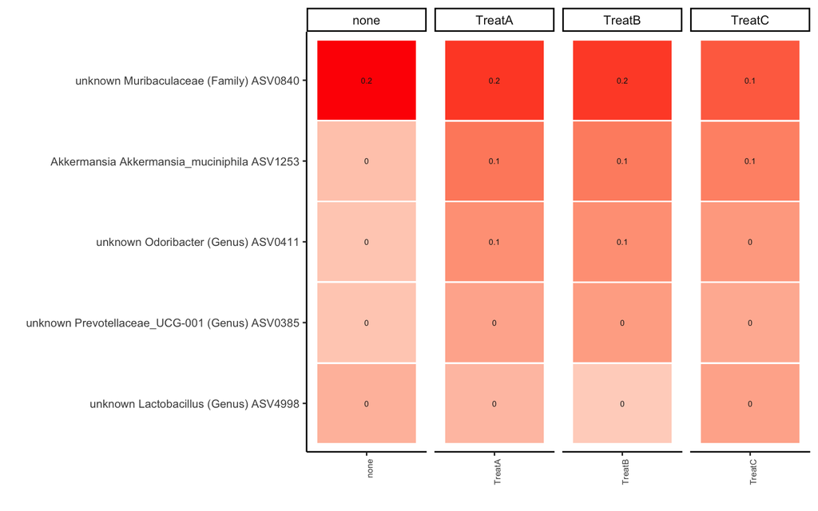

```r
source("https://raw.githubusercontent.com/fconstancias/DivComAnalyses/master/R/phyloseq_heatmap.R")

physeq_1_st %>%
  phyloseq_ampvis_heatmap(physeq = .,
                          facet_by = "treatment_invivo" ,
                          group_by = "treatment_invivo",
                          ntax =  5) -> heat_overall

heat_overall
```

We might be also interested in visualizing the 5 most abundant taxa per groups: per the levels of *treatment_invivo* i.e., “none”, “TreatA”, “TreatB”, “TreatC”. The function `physeq_most_abundant()` returns a vector of the most abundant taxa per levels.

```r
physeq_1_st %>%
  physeq_most_abundant("treatment_invivo",
                       tax_level = "Strain",
                       ntax = 5) -> most_ab_treat

most_ab_treat
```

```
##  [1] "Akkermansia Akkermansia_muciniphila ASV1253"
##  [2] "unknown Alloprevotella (Genus) ASV0365"
##  [3] "unknown Clostridium_sensu_stricto_1 (Genus) ASV0066"
##  [4] "unknown Lachnospiraceae_NK4A136_group (Genus) ASV3104"
##  [5] "unknown Lachnospiraceae_NK4A136_group (Genus) ASV3987"
##  [6] "unknown Lactobacillus (Genus) ASV4998"
##  [7] "unknown Muribaculaceae (Family) ASV0840"
##  [8] "unknown Odoribacter (Genus) ASV0411"
##  [9] "unknown Prevotellaceae_UCG-001 (Genus) ASV0385"
## [10] "unknown Turicibacter (Genus) ASV4836"
```

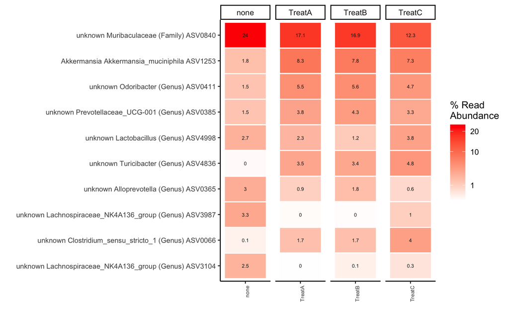

```r
physeq_1_st %>%
  transform_sample_counts(function(x) x/sum(x) * 100) %>% # transform as percentage before filtering
  subset_taxa(Strain %in% most_ab_treat) %>% # extract only the taxa to display - after percentage normalisation
  phyloseq_ampvis_heatmap(physeq = .,
                          transform = FALSE, # extract only the taxa to display - after percentage normalisation
                          facet_by = "treatment_invivo" ,
                          group_by = "treatment_invivo",
                          ntax =  Inf) -> heat_top_taxa_per_group

heat_top_taxa_per_group
```

#### 2.4.6.3 Generate color palette from metadata:

```r
source("https://raw.githubusercontent.com/fconstancias/DivComAnalyses/master/R/phyloseq_varia.R")

physeq_1_st %>%
  generate_color_palette(var = "treatment_invivo",
                         pal = "npg",
                         print = FALSE) -> treat_pal
treat_pal
```

```
##        none      TreatB      TreatA      TreatC
## "#E64B35FF" "#4DBBD5FF" "#00A087FF" "#3C5488FF"
```

We can use `show_col()` from the scales package to visualise the palette. Using `scales::show_col()` allows to run the function without loading the full package.

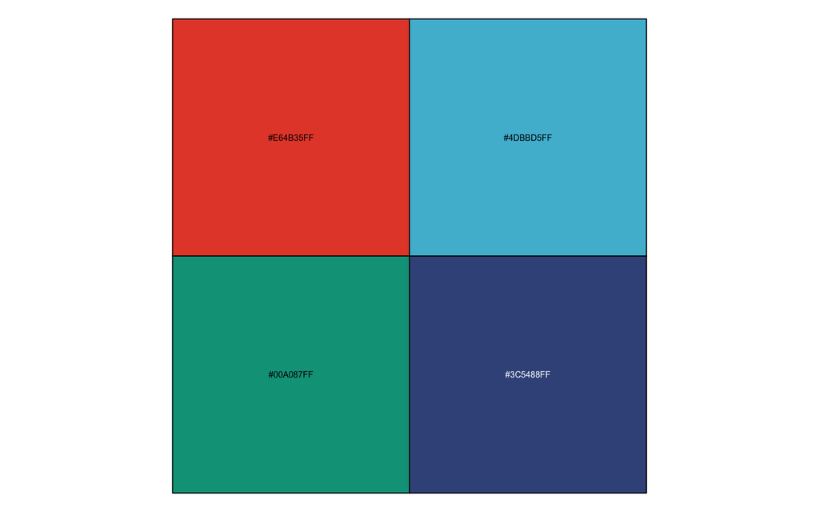

```r
treat_pal %>%
  scales::show_col(.,
                 cex_label = 0.5)
```

```r
source("https://raw.githubusercontent.com/fconstancias/DivComAnalyses/master/R/phyloseq_normalisation.R")

phyloseq_check_lib_size
```

```
## function (physeq, data_color, data_facet, nreads_display, first_n)
## {
##     require(tidyverse)
##     require(speedyseq)
##     if ("SampleID" %in% (physeq %>% sample_data() %>% colnames())) {
##         df <- physeq %>% sample_data() %>% as.matrix() %>% as.data.frame()
##     }
##     else {
##         df <- physeq %>% sample_data() %>% as.matrix() %>% as.data.frame() %>%
##             rownames_to_column("SampleID")
##     }
##     df$LibrarySize <- sample_sums(physeq)
##     df <- df[order(df$LibrarySize), ]
##     df$Index <- seq(nrow(df))
##     p <- ggplot(data = df, aes_string(x = "Index", y = "LibrarySize",
##         color = data_color, label = "SampleID")) + geom_point(size = 0.5) +
##         ggrepel::geom_text_repel(data = df %>% filter(LibrarySize <
##             nreads_display))
##     if (is.null(data_facet) == FALSE) {
##         p <- p + facet_wrap(~get(data_facet), ncol = 1)
##     }
##     p <- p + coord_cartesian(xlim = c(0, first_n)) + geom_hline(yintercept = nreads_display,
##         color = "red", size = 0.5)
##     out <- list(plot = p, df = df)
##     return(out)
## }
```

```r
phyloseq_rarefaction_curves
```

```
## function (physeq, stepsize, color_data, facet_data)
## {
##     require(ampvis2)
##     tax_table(physeq) <- tax_table(physeq)[, c("Kingdom", "Phylum",
##         "Class", "Order", "Family", "Genus", "Species")]
##     p <- physeq %>% phyloseq_to_ampvis2() %>% amp_rarecurve(stepsize = stepsize,
##         color_by = color_data, facet_by = facet_data, facet_scales = "fixed") +
##         ylab("Number of Observed ASVs") + theme_classic() + theme(axis.text.x = element_text(angle = 90,
##         hjust = 1, size = 8))
##     return(p)
## }
```

```r
ggrare
```

```
## function (physeq, step = 10, label = NULL, color = NULL, plot = TRUE,
##     parallel = FALSE, se = TRUE)
## {
##     x <- as(otu_table(physeq), "matrix")
##     if (taxa_are_rows(physeq)) {
##         x <- t(x)
##     }
##     tot <- rowSums(x)
##     S <- rowSums(x > 0)
##     nr <- nrow(x)
##     rarefun <- function(i) {
##         cat(paste("rarefying sample", rownames(x)[i]), sep = "\n")
##         n <- seq(1, tot[i], by = step)
##         if (n[length(n)] != tot[i]) {
##             n <- c(n, tot[i])
##         }
##         y <- vegan::rarefy(x[i, , drop = FALSE], n, se = se)
##         if (nrow(y) != 1) {
##             rownames(y) <- c(".S", ".se")
##             return(data.frame(t(y), Size = n, Sample = rownames(x)[i]))
##         }
##         else {
##             return(data.frame(.S = y[1, ], Size = n, Sample = rownames(x)[i]))
##         }
##     }
##     if (parallel) {
##         out <- mclapply(seq_len(nr), rarefun, mc.preschedule = FALSE)
##     }
##     else {
##         out <- lapply(seq_len(nr), rarefun)
##     }
##     df <- do.call(rbind, out)
##     if (!is.null(sample_data(physeq, FALSE))) {
##         sdf <- as(sample_data(physeq), "data.frame")
##         sdf$Sample <- rownames(sdf)
##         data <- merge(df, sdf, by = "Sample")
##         labels <- data.frame(x = tot, y = S, Sample = rownames(x))
##         labels <- merge(labels, sdf, by = "Sample")
##     }
##     if (length(color) > 1) {
```

[output cut: 12 more lines]

```
##     if (!is.null(label)) {
##         p <- p + geom_text(data = labels, aes_string(x = "x",
##             y = "y", label = label, color = color), size = 4,
##             hjust = 0)
##     }
##     p <- p + geom_line()
##     if (se) {
##         p <- p + geom_ribbon(aes_string(ymin = ".S - .se", ymax = ".S + .se",
##             color = NULL, fill = color), alpha = 0.2)
##     }
##     if (plot) {
##         plot(p)
##     }
##     invisible(p)
## }
```

```r
phyloseq_rarefied_unrarefied_richness
```

```
## function (physeq, measure = "Observed", sample_size = 1000, seed = 123,
##     color_data = NULL, fill_data = NULL, shape_data = NULL)
## {
##     require(phyloseq)
##     physeq_rarefied <- physeq %>% rarefy_even_depth(rngseed = seed,
##         sample.size = sample_size)
##     physeq <- prune_samples(sample_sums(physeq) >= sample_size,
##         physeq)
##     p <- data.frame(a = estimate_richness(physeq_rarefied, measures = measure)[,
##         1], b = estimate_richness(physeq, measures = measure)[,
##         1], sample_data(physeq)) %>% ggplot(aes(x = a, y = b)) +
##         geom_point(aes_string(color = color_data, fill = fill_data,
##             shape = shape_data)) + geom_smooth(method = "lm",
##         level = 0.95) + labs(x = paste0("\nRarefied ", measure),
##         y = paste0("UN-Rarefied ", measure, "\n")) + theme_minimal()
##     return(p)
## }
```

```r
phyloseq_filter_samples
```

```
## function (physeq, thrs)
## {
##     require(phyloseq)
##     require(tidyverse)
##     if (class(physeq) == "phyloseq") {
##         df <- physeq %>% otu_table() %>% data.frame() %>% t() %>%
##             as.data.frame()
##         tax <- taxa_names(physeq)
##         ntax <- ntaxa(physeq)
##         samples <- sample_names(physeq)
##     }
##     else {
##         df = physeq
##         samples <- colnames(df)
##         ntax <- nrow(df)
##         tax <- rownames(df)
##     }
##     results_all <- df %>% rownames_to_column("ASV") %>% select(ASV)
##     results_all_2 <- results_all
##     results_all_3 <- results_all
##     for (c in samples) {
##         tpm <- df %>% rownames_to_column("ASV") %>% select(ASV,
##             c) %>% arrange(-get(c)) %>% mutate(percent = get(c)/sum(get(c))) %>%
##             mutate(Accumulated_pc = cumsum(percent)) %>% mutate(Common_Rare = ifelse(Accumulated_pc <=
##             thrs/100, "Common", "Rare"))
##         filtter_sample_common <- tpm %>% mutate(new_count = ifelse(Common_Rare ==
##             "Common", get(c), 0)) %>% select(-percent, -Accumulated_pc,
##             -!!c, -Common_Rare) %>% dplyr::rename(`:=`(!!c, new_count))
##         filtter_sample_rare <- tpm %>% mutate(new_count = ifelse(Common_Rare ==
##             "Rare", get(c), 0)) %>% select(-percent, -Accumulated_pc,
##             -!!c, -Common_Rare) %>% dplyr::rename(`:=`(!!c, new_count))
##         results <- tpm %>% select(-percent, -Accumulated_pc,
##             -!!c) %>% dplyr::rename(`:=`(!!c, Common_Rare))
##         results_all <- full_join(results_all, results)
##         results_all_2 <- full_join(results_all_2, filtter_sample_common)
##         results_all_3 <- full_join(results_all_3, filtter_sample_rare)
##     }
##     commons <- results_all %>% pivot_longer(samples) %>% filter(value ==
##         "Common") %>% pull(ASV) %>% unique()
##     rare <- setdiff(tax, commons)
```

[output cut: 12 more lines]

```
##             0) > 0, TRUE)
##         out <- list(global_common = physeq_common, global_rare = physeq_rare,
##             per_sample_common = physeq_persample_common, per_sample_rare = physeq_persample_rare)
##         return(out)
##     }
##     else {
##         df_common <- df %>% rownames_to_column("ASV") %>% filter(ASV %in%
##             commons)
##         df_rare <- df %>% rownames_to_column("ASV") %>% filter(ASV %in%
##             rare)
##         out <- list(global_common = df_common, global_rare = df_rare,
##             per_sample_common = results_all_2, per_sample_rare = results_all_3)
##         return(out)
##     }
## }
```

```r
phyloseq_filter_per_sample_OTU
```

```
## function (physeq, thrs = 0.1)
## {
##     require(phyloseq)
##     require(tidyverse)
##     df <- physeq %>% otu_table() %>% data.frame() %>% data.frame()
##     tax <- taxa_names(physeq)
##     ntax <- ntaxa(physeq)
##     samples <- sample_names(physeq)
##     results_all <- df %>% rownames_to_column("ASV") %>% select(ASV)
##     for (c in samples) {
##         tmp <- df %>% rownames_to_column("ASV") %>% select(ASV,
##             c) %>% arrange(-get(c)) %>% mutate(percent = get(c)/sum(get(c))) %>%
##             mutate(Accumulated_pc = cumsum(percent)) %>% mutate(above_below = ifelse(percent <=
##             thrs/100, "below", "above")) %>% mutate(`:=`(!!c,
##             ifelse(above_below == "above", get(c), 0)))
##         results <- tmp %>% select(-percent, -Accumulated_pc,
##             !!c, -above_below)
##         results_all <- full_join(results_all, results)
##     }
##     phyloseq_filt <- merge_phyloseq(results_all %>% column_to_rownames("ASV") %>%
##         as.matrix() %>% otu_table(taxa_are_rows = TRUE), physeq %>%
##         tax_table(), physeq %>% sample_data()) %>% filter_taxa(function(x) sum(x >
##         0) > 0, TRUE)
##     if (!is.null(physeq@refseq)) {
##         phyloseq_filt <- merge_phyloseq(phyloseq_filt, physeq %>%
##             phy_tree())
##     }
##     out <- phyloseq_filt
##     return(out)
## }
```

```r
phyloseq_remove_chloro_mitho
```

```
## function (physeq)
## {
##     your_phyloseq_clean <- physeq %>% subset_taxa(Order != "Chloroplast" |
##         Family != "Mitochondria")
##     return(your_phyloseq_clean)
## }
```

```r
phyloseq_density_normalize
```

```
## function (physeq = physeq, value_idx = "norm", remove.na = TRUE,
##     set.na.0 = FALSE)
## {
##     require(tidyverse)
##     require(phyloseq)
##     if (remove.na == TRUE) {
##         physeq <- prune_samples(!is.na(physeq %>% get_variable(value_idx)),
##             physeq)
##     }
##     df_OTU_col = colnames(phyloseq::otu_table(physeq))
##     df_OTU = phyloseq2df(physeq, phyloseq::otu_table)
##     df_OTU_rn = rownames(df_OTU)
##     df_OTU = as.data.frame(apply(df_OTU, 2, as.Num))
##     rownames(df_OTU) = df_OTU_rn
##     df_OTU = tss(df_OTU)
##     sample_idx = "tmp"
##     qPCR <- physeq %>% sample_data() %>% data.frame() %>% rownames_to_column(sample_idx)
##     rownames(qPCR) = make.names(qPCR[, sample_idx])
##     qPCR = qPCR[colnames(df_OTU), ]
##     qPCR_vals = qPCR[, value_idx]
##     if (length(qPCR_vals) != ncol(df_OTU)) {
##         stop("length qPCR_vals (", length(qPCR_vals), ") != ncol df_OTU (",
##             ncol(df_OTU), ")")
##     }
##     df_OTU = sweep(df_OTU %>% as.data.frame, 2, qPCR_vals, "*")
##     df_OTU = apply(df_OTU, 2, function(x) round(x, 0))
##     colnames(df_OTU) = df_OTU_col
##     if (set.na.0 == TRUE) {
##         df_OTU[is.na(df_OTU)] = 0
##     }
##     tree = phyloseq::phy_tree(physeq, errorIfNULL = FALSE)
##     tax = phyloseq::tax_table(physeq, errorIfNULL = FALSE)
##     sam = phyloseq::sample_data(physeq, errorIfNULL = FALSE)
##     physeq2 = phyloseq::phyloseq(phyloseq::otu_table(df_OTU,
##         taxa_are_rows = TRUE), phyloseq::phy_tree(tree, errorIfNULL = FALSE),
##         phyloseq::tax_table(tax, errorIfNULL = FALSE), phyloseq::sample_data(sam,
##             errorIfNULL = FALSE))
##     return(physeq2)
## }
```

update metadata

```r
source("https://raw.githubusercontent.com/fconstancias/DivComAnalyses/master/R/phyloseq_taxa_tests.R")

phyloseq_run_DESeq2_pair_plots_formula
```

```
## function (ps, taxrank = "Strain", sumfilter = 10, prevfilter = 0.33,
##     formula = paste("age", "deit", sep = " ", collapse = " + "),
##     fittype = "parametric", taxnames_rm = c("unknown, Incertae Sedis"),
##     contrast = c("diet", "high ALA", "low ALA"), level_facet = "Class",
##     Group2 = NULL, gm_mean = FALSE, Group_group = Group, boxplot_colors = NULL)
## {
##     require(tidyverse)
##     require(DESeq2)
##     ps_temp <- ps %>% filter_taxa(function(x) sum(x > 0) > 0,
##         TRUE) %>% speedyseq::tax_glom(taxrank = taxrank)
##     print(paste0("from ", ntaxa(ps), " features, ", ntaxa(ps_temp),
##         " were kept after removing features with 0 abundances and  taxa agglomeration"))
##     if (taxrank != "Strain") {
##         ps_temp <- prune_taxa(data.frame(tax_table(ps_temp)[,
##             taxrank]) %>% dplyr::filter(!get(taxrank) %in% taxnames_rm) %>%
##             rownames(), ps_temp)
##         taxa_names(ps_temp) <- tax_table(ps_temp)[, taxrank]
##     }
##     ps_filtered <- ps_temp %>% filter_taxa(function(x) {
##         sum(x > sumfilter) > prevfilter * nsamples(ps_temp)
##     }, prune = TRUE)
##     cds <- ps_filtered %>% phyloseq_to_deseq2(as.formula(paste0("~ ",
##         formula)))
##     print(paste0("from ", ntaxa(ps_temp), " features, ", ntaxa(ps_filtered),
##         " were kept after taxa agglomeration, sum filter and prevalence filtering"))
##     if (gm_mean) {
##         gm_mean = function(x, na.rm = TRUE) {
##             exp(sum(log(x[x > 0]), na.rm = na.rm)/length(x))
##         }
##         geoMeans = apply(counts(cds), 1, gm_mean)
##         cds = estimateSizeFactors(cds, geoMeans = geoMeans)
##     }
##     if (gm_mean) {
##         gm_mean = function(x, na.rm = TRUE) {
##             exp(sum(log(x[x > 0]), na.rm = na.rm)/length(x))
##         }
##         geoMeans = apply(counts(cds), 1, gm_mean)
##         cds = estimateSizeFactors(cds, geoMeans = geoMeans)
##     }
##     dds <- cds %>% DESeq(fitType = fittype)
```

[output cut: 33 more lines]

```
##         boxplots <- lapply(as.list(taxa_names(ps_tmp)), FUN = phyloseq_boxplot_abundance,
##             ps = ps_tmp, x = Group, color = Group_group, level = taxrank,
##             line = NULL, violin = FALSE, show.points = TRUE,
##             colors = boxplot_colors)
##         names(boxplots) <- taxa_names(ps_tmp)
##         out <- list(ps_filtered = ps_filtered, boxplots = boxplots,
##             volcano_plot = volcano_plot, heatmap = heatmap, results = resuls_complete)
##     }
##     else {
##         print("No singinifcant features found")
##         out <- list(ps_filtered = ps_filtered, results = resuls_complete)
##     }
##     return(out)
##     detach("package:DESeq2", unload = TRUE)
## }
```

```r
phyloseq_Maaslin2
```

```
## function (phyloseq, taxnames_rm = c("unknown, Incertae Sedis"),
##     min_abundance = 0, min_prevalence = 0.1, min_variance = 0,
##     random_effects = NULL, fixed_effects = c("treatment"), max_significance = 0.25,
##     normalization = "TSS", transform = "LOG", analysis_method = "LM",
##     correction = "BH", standardize = TRUE, cores = 4, plot_heatmap = FALSE,
##     plot_scatter = TRUE, heatmap_first_n = 50, output_dir = "~/test_masslin2/")
## {
##     require(tidyverse)
##     require(Maaslin2)
##     require(phyloseq)
##     out <- Maaslin2(phyloseq %>% otu_table() %>% t(), phyloseq %>%
##         sample_data() %>% data.frame(), output_dir, analysis_method = analysis_method,
##         normalization = normalization, transform = transform,
##         min_abundance = min_abundance, min_prevalence = min_prevalence,
##         min_variance = min_variance, random_effects = random_effects,
##         fixed_effects = fixed_effects, correction = correction,
##         standardize = standardize, max_significance = max_significance,
##         cores = cores, heatmap_first_n = heatmap_first_n, plot_heatmap = plot_heatmap,
##         plot_scatter = plot_scatter)
##     return(out)
## }
```

```r
phyloseq_boxplot_abundance
```

```
## function (ps, x, y, level = "Strain", color = NULL, line = NULL,
##     violin = FALSE, na.rm = FALSE, show.points = TRUE, size = 2,
##     alpha = 1, log10 = TRUE, colors = NULL)
## {
##     require(tidyverse)
##     require(microbiome)
##     colors = colors
##     change <- xvar <- yvar <- linevar <- colorvar <- NULL
##     pseq <- ps
##     taxa_names(pseq) <- tax_table(pseq)[, level]
##     otu <- microbiome::abundances(pseq)
##     df <- microbiome::meta(pseq)
##     df$xvar <- df[[x]]
##     if (!is.factor(df[[x]])) {
##         df$xvar <- factor(as.character(df$xvar))
##     }
##     if (y %in% taxa_names(pseq)) {
##         df$yvar <- as.vector(unlist(otu[y, ]))
##     }
##     else {
##         df$yvar <- as.vector(unlist(sample_data(pseq)[, y]))
##     }
##     if (na.rm) {
##         df <- subset(df, !is.na(xvar))
##         df <- subset(df, !is.na(yvar))
##     }
##     if (nrow(df) == 0) {
##         warning("No sufficient data for plotting available. \n            Returning an empty plot.")
##         return(ggplot())
##     }
##     df$xvar <- factor(df$xvar)
##     ylab <- y %>% stringr::str_replace("unknown", "un.") %>%
##         stringr::str_trunc(35, side = "center")
##     p <- ggplot(df, aes(x = xvar, y = yvar)) + theme_classic() +
##         ylab(ylab)
##     if (show.points) {
##         p <- p + geom_jitter(size = size, alpha = alpha, aes_string(colour = color,
##             fill = color))
##     }
##     if (!violin) {
```

[output cut: 17 more lines]

```
##     }
##     if (log10) {
##         p <- p + scale_y_log10() + ylab(paste0(ylab)) + theme(legend.position = "none")
##     }
##     if (is.null(colors)) {
##         p <- p + xlab(x) + theme(legend.position = "none")
##         return(p)
##     }
##     else {
##         p <- p + xlab(NULL) + theme(legend.position = "none") +
##             scale_colour_manual(values = colors) + scale_fill_manual(values = colors)
##         return(p)
##     }
##     detach("package:microbiome", unload = TRUE)
## }
```

```r
phyloseq_A_B_ratio
```

```
## function (ps = GlobalPatterns, level = "Phylum", a_name = "Bacteroidetes",
##     b_name = "Firmicutes", Group = "SampleType", sampleID = FALSE)
## {
##     require(microbiome)
##     require(tidyverse)
##     require(ggpubr)
##     tmp <- microbiome::transform(microbiome::aggregate_taxa(ps,
##         level = level), "compositional")
##     a <- microbiome::abundances(tmp)[a_name, ]
##     b <- microbiome::abundances(tmp)[b_name, ]
##     name <- paste0(a_name, "_", b_name)
##     tmp <- a/b %>% data.frame() %>% dplyr::rename(`:=`(!!name,
##         "."))
##     df <- tmp %>% tibble::rownames_to_column("sample") %>% dplyr::full_join(ps %>%
##         sample_data() %>% data.frame() %>% rownames_to_column("sample"),
##         by = c(sample = "sample"))
##     p <- df %>% ggplot(aes_string(x = Group, y = name, colour = Group,
##         fill = Group, label = "sample")) + geom_boxplot(outlier.colour = NA,
##         alpha = 0.8, position = position_dodge(width = 0.7)) +
##         geom_jitter(size = 2, alpha = 1, position = position_jitterdodge(1)) +
##         ylab(paste0(paste0(a_name, "/", b_name), " ratio")) +
##         xlab(NULL) + theme(axis.text.x = element_blank()) + theme_classic()
##     if (sampleID == TRUE) {
##         p <- p + ggrepel::geom_text_repel(position = position_jitterdodge(1),
##             size = 2, segment.color = "grey50")
##     }
##     KW_tests <- ggpubr::compare_means(as.formula(paste0(name,
##         " ~ ", Group)), data = df, method = "wilcox.test")
##     return(out = list(plot = p, df = df, KW_tests = KW_tests))
##     detach("package:microbiome", unload = TRUE)
##     detach("package:ggpubr", unload = TRUE)
## }
```

```r
phyloseq_run_compare_means
```

```
## function (tmp = tmp, group = group, comp = comp, prev = prev,
##     varcoef = varcoef)
## {
##     out = NULL
##     out <- vector("list", length(tmp %>% get_variable(group) %>%
##         levels()))
##     names(out) <- tmp %>% get_variable(group) %>% levels()
##     for (tp in tmp %>% get_variable(group) %>% unique()) {
##         tmp2 <- prune_samples(get_variable(tmp, group) == tp,
##             tmp) %>% transform_sample_counts(function(x) x/sum(x) *
##             100) %>% filter_taxa(function(x) sum(x > 0) > (prev *
##             length(x)), TRUE) %>% filter_taxa(function(x) sd(x)/mean(x) >
##             varcoef, TRUE) %>% psmelt()
##         results <- ggpubr::compare_means(formula = as.formula(paste0("Abundance ~ ",
##             paste0(comp))), group.by = c("Species"), data = tmp2,
##             method = "wilcox.test", p.adjust.method = "fdr") %>%
##             select(-.y., -p.format, -p.signif) %>% arrange(p.adj) %>%
##             mutate(signif = ifelse(p.adj <= 0.05, "SIGN", "NS")) %>%
##             mutate(Site = tp)
##         out[[tp]] <- results
##     }
##     return(out)
## }
```

```r
phyloseq_run_Deseq
```

```
## function (tmp = tmp, group = group, comp = comp, prev = prev,
##     varcoef = varcoef, A = A, vsB = vsB)
## {
##     out = NULL
##     out <- vector("list", length(tmp %>% get_variable(group) %>%
##         levels()))
##     names(out) <- tmp %>% get_variable(group) %>% levels()
##     for (tp in tmp %>% get_variable(group) %>% unique()) {
##         cds <- prune_samples(get_variable(tmp, group) == tp,
##             tmp) %>% filter_taxa(function(x) sum(x > 0) > (prev *
##             length(x)), TRUE) %>% filter_taxa(function(x) sd(x)/mean(x) >
##             varcoef, TRUE) %>% phyloseq_to_deseq2(as.formula(paste0("~  ",
##             paste0(comp))))
##         gm_mean = function(x, na.rm = TRUE) {
##             exp(sum(log(x[x > 0]), na.rm = na.rm)/length(x))
##         }
##         geoMeans = apply(counts(cds), 1, gm_mean)
##         cds = estimateSizeFactors(cds, geoMeans = geoMeans)
##         dds <- DESeq(cds, fitType = "local")
##         results <- results(dds, contrast = c(comp, A, vsB), tidy = TRUE) %>%
##             dplyr::rename(OTU = row) %>% dplyr::rename(p.adj = padj) %>%
##             arrange(p.adj) %>% mutate(signif = ifelse(p.adj <=
##             0.05, "SIGN", "NS")) %>% mutate(Site = tp)
##         out[[tp]] <- results
##     }
##     return(out)
## }
```

```r
phyloseq_run_ALDEx2
```

```
## function (tmp = tmp, group = group, comp = comp, prev = prev,
##     varcoef = varcoef, mc = mc, denom = denom)
## {
##     require(ALDEx2)
##     out = NULL
##     out <- vector("list", length(tmp %>% get_variable(group) %>%
##         levels()))
##     names(out) <- tmp %>% get_variable(group) %>% levels()
##     print(out)
##     for (tp in tmp %>% get_variable(group) %>% unique()) {
##         print(tp)
##         cds <- prune_samples(get_variable(tmp, group) == tp,
##             tmp) %>% filter_taxa(function(x) sum(x > 0) > (prev *
##             length(x)), TRUE) %>% filter_taxa(function(x) sd(x)/mean(x) >
##             varcoef, TRUE)
##         x <- ALDEx2::aldex.clr(data.frame(phyloseq::otu_table(cds)),
##             phyloseq::sample_data(cds) %>% data.frame() %>% pull(comp),
##             mc.samples = mc, denom = denom, verbose = F, useMC = TRUE)
##         aldex2_da <- x %>% ALDEx2::aldex.kw(useMC = TRUE)
##         aldex2_tax <- aldex2_da %>% rownames_to_column(var = "Species") %>%
##             dplyr::mutate(site = tp) %>% left_join(tax_table(tmp) %>%
##             data.frame() %>% rownames_to_column("OTU"), by = "Species",
##             suffix = c("", ".y"))
##         out[[tp]] <- aldex2_tax
##     }
##     return(out)
## }
```

```r
phyloseq_correlate_taxa
```

```
## function (ps_tmp, log10 = TRUE, tax_glom = FALSE, grouping_column,
##     adjustment = 3, num_taxa = 20, cor_variables, method = "spearman")
## {
##     require(tidyverse)
##     if (tax_glom != FALSE) {
##         ps_tmp <- ps_tmp %>% tax_glom(taxrank = tax_glom)
##     }
##     tmp2 <- ps_tmp %>% transform_sample_counts(function(x) x/sum(x) *
##         100)
##     if (log10 == TRUE) {
##         tmp2 <- tmp2 %>% microbiome::transform("log10")
##     }
##     env.taxa.cor <- tmp2 %>% phyloseq_taxa_env_correlation(grouping_column = grouping_column,
##         method = method, pvalue.threshold = 0.05, padjust.method = "fdr",
##         adjustment = adjustment, num.taxa = num_taxa, select.variables = cor_variables)
##     p <- phyloseq_plot_taxa_env_correlation(env.taxa.cor)
##     if (tax_glom == FALSE) {
##         tmp <- as(tax_table(ps_tmp), "matrix") %>% data.frame()
##         p <- p$data %>% dplyr::left_join(tmp %>% rownames_to_column("ASV"),
##             by = c(Taxa = "ASV")) %>% dplyr::select(-Taxa) %>%
##             dplyr::rename(Taxa = Strain) %>% phyloseq_plot_taxa_env_correlation() +
##             scale_fill_gradient2(low = "#2C7BB6", high = "#D7191C",
##                 mid = "white", midpoint = 0, limit = c(-1, 1),
##                 space = "Lab")
##     }
##     if (tax_glom != FALSE) {
##         tmp <- as(tax_table(ps_tmp), "matrix") %>% data.frame()
##         p <- p$data %>% dplyr::left_join(tmp %>% rownames_to_column("ASV"),
##             by = c(Taxa = "ASV")) %>% dplyr::select(-Taxa) %>%
##             dplyr::rename(`:=`(Taxa, !!tax_glom)) %>% phyloseq_plot_taxa_env_correlation() +
##             scale_fill_gradient2(low = "#2C7BB6", high = "#D7191C",
##                 mid = "white", midpoint = 0, limit = c(-1, 1),
##                 space = "Lab")
##     }
##     return(list(plot = p, table = env.taxa.cor))
## }
```

```r
source("https://raw.githubusercontent.com/fconstancias/DivComAnalyses/master/R/phyloseq_alpha.R")

phyloseq_alphas
```

```
## function (physeq, phylo)
## {
##     require(metagMisc)
##     require(microbiome)
##     if (phylo == TRUE) {
##         tmp <- bind_cols(microbiome::meta(physeq) %>% rownames_to_column("id1"),
##             microbiome::alpha(physeq, index = c("diversity_inverse_simpson",
##                 "diversity_shannon", "evenness_pielou", "diversity_coverage")) %>%
##                 rownames_to_column("id2"), phyloseq::estimate_richness(physeq,
##                 measures = c("Observed", "Chao1", "ACE")) %>%
##                 as.data.frame() %>% rownames_to_column("id3"),
##             metagMisc::phyloseq_phylo_div(physeq) %>% rownames_to_column("id4"))
##         tmp2 <- metagMisc::phyloseq_phylo_ses(physeq, package = "PhyloMeasures",
##             verbose = FALSE)
##         tmp3 <- left_join(tmp, tmp2, by = c(id1 = "SampleID"),
##             suffix = c("", "_PM"), keep = TRUE)
##         alpha <- tmp3 %>% mutate(bNTI = (MNTD_PM - MNTD.rand.mean)/MNTD.rand.sd)
##         return(alpha)
##     }
##     else {
##         alpha <- bind_cols(microbiome::meta(physeq) %>% rownames_to_column("id"),
##             microbiome::alpha(physeq) %>% rownames_to_column("id"),
##             phyloseq::estimate_richness(physeq, measures = c("Observed",
##                 "Chao1", "ACE")) %>% as.data.frame() %>% rownames_to_column("id"))
##         return(alpha)
##         detach("package:metagMisc", unload = TRUE)
##         detach("package:microbiome", unload = TRUE)
##     }
## }
```

```r
plot_alphas
```

```
## function (alphas, measure = c("Observed", "diversity_shannon"),
##     x_group, colour_group, fill_group, shape_group, facet_group = FALSE,
##     test_group, test_group_2)
## {
##     p <- alphas %>% pivot_longer(cols = all_of(measure), values_to = "value",
##         names_to = "alphadiversiy", values_drop_na = TRUE) %>%
##         mutate(alphadiversiy = fct_relevel(alphadiversiy, measure)) %>%
##         ggplot(aes_string(x_group, "value", colour = colour_group,
##             fill = fill_group)) + geom_boxplot(outlier.colour = NA,
##         alpha = 0.7) + geom_jitter(size = 1, position = position_jitterdodge(dodge.width = 1),
##         aes_string(shape = shape_group)) + ylab("Diversity index") +
##         xlab(NULL) + theme_light()
##     p <- p + facet_grid(as.formula(paste0("alphadiversiy ~ ",
##         paste(facet_group))), scales = "free_y", space = "fixed")
##     stat <- ggpubr::compare_means(formula = as.formula(paste0("value ~ ",
##         paste0(test_group))), group.by = c("alphadiversiy", test_group_2),
##         data = p$data, method = "wilcox.test", p.adjust.method = "fdr") %>%
##         select(-.y., -p.format, -p.signif) %>% arrange(p) %>%
##         mutate(signif = ifelse(p.adj <= 0.05, "SIGN", "NS"))
##     out <- list(plot = p, stat = stat)
##     return(out)
## }
```

```r
correlate_alpha
```

```
## function (alphas_all, colnums_to_plot, colour, shape, method)
## {
##     my_fn <- function(data, mapping, ...) {
##         p <- ggplot(data = data, mapping = mapping) + geom_point() +
##             geom_smooth(method = lm, ...)
##         p
##     }
##     corplot <- alphas_all %>% GGally::ggpairs(columns = colnums_to_plot,
##         progress = FALSE, upper = list(continuous = GGally::wrap("cor",
##             method = method)), lower = list(continuous = my_fn))
##     return(corplot)
## }
```

```r
plot_taxa_abundances_over_time
```

```
## function (physeq = physeq, taxa_level, taxa_to_plot, time_column,
##     other_columns_to_plot = NULL, axis_transform = TRUE, transformation = NULL,
##     plot_total = FALSE, data_facet1 = NULL, data_facet2 = NULL,
##     n_facet_row = NULL, n_facet_col = NULL)
## {
##     require(phyloseq)
##     require(tidyverse)
##     if (taxa_level == "Species") {
##         otu.table <- as(otu_table(physeq), "matrix") %>% data.frame(check.names = FALSE) %>%
##             rownames_to_column("ASV")
##         sample.data <- as(sample_data(physeq), "matrix") %>%
##             data.frame(check.names = FALSE) %>% rownames_to_column("SampleID")
##         for (i in taxa_to_plot) {
##             sample.data <- sample.data %>% mutate(`:=`("{i}",
##                 as.numeric(otu.table[otu.table$ASV == i, -1])))
##         }
##         if (plot_total == TRUE) {
##             sample.data <- sample.data %>% mutate(ASV_total = 0)
##             for (i in 1:length(taxa_to_plot)) {
##                 sample.data <- sample.data %>% mutate(ASV_total = ASV_total +
##                   .data[[taxa_to_plot[i]]])
##             }
##         }
##         sample.data <- sample.data %>% mutate(`:=`("{time_column}",
##             as.numeric(get(time_column))))
##         for (i in other_columns_to_plot) {
##             sample.data <- sample.data %>% mutate(`:=`("{i}",
##                 as.numeric(.data[[i]])))
##         }
##         plot.df <- sample.data %>% pivot_longer(cols = c(starts_with("ASV"),
##             all_of(other_columns_to_plot)), names_to = "Data",
##             values_to = "Abundances") %>% arrange(get(time_column)) %>%
##             remove_missing(vars = "Abundances")
##         if (axis_transform == TRUE) {
##             plot <- ggplot(data = plot.df, mapping = aes(color = Data,
##                 shape = Abundances == 0)) + geom_point(mapping = aes(x = .data[[time_column]],
##                 y = Abundances), alpha = 0.8) + geom_path(mapping = aes(x = .data[[time_column]],
##                 y = Abundances, group = Data), alpha = 0.8) +
##                 scale_y_continuous(trans = transformation)
##         }
```

[output cut: 69 more lines]

```
##         if (is.null(data_facet1) & !is.null(data_facet2)) {
##             plot <- plot + facet_wrap(~get(data_facet2), ncol = n_facet_col,
##                 nrow = n_facet_row)
##         }
##         else if (is.null(data_facet2) & !is.null(data_facet1)) {
##             plot <- plot + facet_wrap(~get(data_facet1), ncol = n_facet_col,
##                 nrow = n_facet_row)
##         }
##         else if (!is.null(data_facet1) & !is.null(data_facet2)) {
##             plot <- plot + facet_wrap(get(data_facet1) ~ get(data_facet2),
##                 ncol = n_facet_col, nrow = n_facet_row)
##         }
##     }
##     return(out <- list(plot = plot, plot.df = plot.df))
## }
```

```r
source("https://raw.githubusercontent.com/fconstancias/DivComAnalyses/master/R/phyloseq_alpha.R")

phyloseq_alphas
```

```
## function (physeq, phylo)
## {
##     require(metagMisc)
##     require(microbiome)
##     if (phylo == TRUE) {
##         tmp <- bind_cols(microbiome::meta(physeq) %>% rownames_to_column("id1"),
##             microbiome::alpha(physeq, index = c("diversity_inverse_simpson",
##                 "diversity_shannon", "evenness_pielou", "diversity_coverage")) %>%
##                 rownames_to_column("id2"), phyloseq::estimate_richness(physeq,
##                 measures = c("Observed", "Chao1", "ACE")) %>%
##                 as.data.frame() %>% rownames_to_column("id3"),
##             metagMisc::phyloseq_phylo_div(physeq) %>% rownames_to_column("id4"))
##         tmp2 <- metagMisc::phyloseq_phylo_ses(physeq, package = "PhyloMeasures",
##             verbose = FALSE)
##         tmp3 <- left_join(tmp, tmp2, by = c(id1 = "SampleID"),
##             suffix = c("", "_PM"), keep = TRUE)
##         alpha <- tmp3 %>% mutate(bNTI = (MNTD_PM - MNTD.rand.mean)/MNTD.rand.sd)
##         return(alpha)
##     }
##     else {
##         alpha <- bind_cols(microbiome::meta(physeq) %>% rownames_to_column("id"),
##             microbiome::alpha(physeq) %>% rownames_to_column("id"),
##             phyloseq::estimate_richness(physeq, measures = c("Observed",
##                 "Chao1", "ACE")) %>% as.data.frame() %>% rownames_to_column("id"))
##         return(alpha)
##         detach("package:metagMisc", unload = TRUE)
##         detach("package:microbiome", unload = TRUE)
##     }
## }
```

```r
plot_alphas
```

```
## function (alphas, measure = c("Observed", "diversity_shannon"),
##     x_group, colour_group, fill_group, shape_group, facet_group = FALSE,
##     test_group, test_group_2)
## {
##     p <- alphas %>% pivot_longer(cols = all_of(measure), values_to = "value",
##         names_to = "alphadiversiy", values_drop_na = TRUE) %>%
##         mutate(alphadiversiy = fct_relevel(alphadiversiy, measure)) %>%
##         ggplot(aes_string(x_group, "value", colour = colour_group,
##             fill = fill_group)) + geom_boxplot(outlier.colour = NA,
##         alpha = 0.7) + geom_jitter(size = 1, position = position_jitterdodge(dodge.width = 1),
##         aes_string(shape = shape_group)) + ylab("Diversity index") +
##         xlab(NULL) + theme_light()
##     p <- p + facet_grid(as.formula(paste0("alphadiversiy ~ ",
##         paste(facet_group))), scales = "free_y", space = "fixed")
##     stat <- ggpubr::compare_means(formula = as.formula(paste0("value ~ ",
##         paste0(test_group))), group.by = c("alphadiversiy", test_group_2),
##         data = p$data, method = "wilcox.test", p.adjust.method = "fdr") %>%
##         select(-.y., -p.format, -p.signif) %>% arrange(p) %>%
##         mutate(signif = ifelse(p.adj <= 0.05, "SIGN", "NS"))
##     out <- list(plot = p, stat = stat)
##     return(out)
## }
```

```r
correlate_alpha
```

```
## function (alphas_all, colnums_to_plot, colour, shape, method)
## {
##     my_fn <- function(data, mapping, ...) {
##         p <- ggplot(data = data, mapping = mapping) + geom_point() +
##             geom_smooth(method = lm, ...)
##         p
##     }
##     corplot <- alphas_all %>% GGally::ggpairs(columns = colnums_to_plot,
##         progress = FALSE, upper = list(continuous = GGally::wrap("cor",
##             method = method)), lower = list(continuous = my_fn))
##     return(corplot)
## }
```

```r
plot_taxa_abundances_over_time
```

```
## function (physeq = physeq, taxa_level, taxa_to_plot, time_column,
##     other_columns_to_plot = NULL, axis_transform = TRUE, transformation = NULL,
##     plot_total = FALSE, data_facet1 = NULL, data_facet2 = NULL,
##     n_facet_row = NULL, n_facet_col = NULL)
## {
##     require(phyloseq)
##     require(tidyverse)
##     if (taxa_level == "Species") {
##         otu.table <- as(otu_table(physeq), "matrix") %>% data.frame(check.names = FALSE) %>%
##             rownames_to_column("ASV")
##         sample.data <- as(sample_data(physeq), "matrix") %>%
##             data.frame(check.names = FALSE) %>% rownames_to_column("SampleID")
##         for (i in taxa_to_plot) {
##             sample.data <- sample.data %>% mutate(`:=`("{i}",
##                 as.numeric(otu.table[otu.table$ASV == i, -1])))
##         }
##         if (plot_total == TRUE) {
##             sample.data <- sample.data %>% mutate(ASV_total = 0)
##             for (i in 1:length(taxa_to_plot)) {
##                 sample.data <- sample.data %>% mutate(ASV_total = ASV_total +
##                   .data[[taxa_to_plot[i]]])
##             }
##         }
##         sample.data <- sample.data %>% mutate(`:=`("{time_column}",
##             as.numeric(get(time_column))))
##         for (i in other_columns_to_plot) {
##             sample.data <- sample.data %>% mutate(`:=`("{i}",
##                 as.numeric(.data[[i]])))
##         }
##         plot.df <- sample.data %>% pivot_longer(cols = c(starts_with("ASV"),
##             all_of(other_columns_to_plot)), names_to = "Data",
##             values_to = "Abundances") %>% arrange(get(time_column)) %>%
##             remove_missing(vars = "Abundances")
##         if (axis_transform == TRUE) {
##             plot <- ggplot(data = plot.df, mapping = aes(color = Data,
##                 shape = Abundances == 0)) + geom_point(mapping = aes(x = .data[[time_column]],
##                 y = Abundances), alpha = 0.8) + geom_path(mapping = aes(x = .data[[time_column]],
##                 y = Abundances, group = Data), alpha = 0.8) +
##                 scale_y_continuous(trans = transformation)
##         }
```

[output cut: 69 more lines]

```
##         if (is.null(data_facet1) & !is.null(data_facet2)) {
##             plot <- plot + facet_wrap(~get(data_facet2), ncol = n_facet_col,
##                 nrow = n_facet_row)
##         }
##         else if (is.null(data_facet2) & !is.null(data_facet1)) {
##             plot <- plot + facet_wrap(~get(data_facet1), ncol = n_facet_col,
##                 nrow = n_facet_row)
##         }
##         else if (!is.null(data_facet1) & !is.null(data_facet2)) {
##             plot <- plot + facet_wrap(get(data_facet1) ~ get(data_facet2),
##                 ncol = n_facet_col, nrow = n_facet_row)
##         }
##     }
##     return(out <- list(plot = plot, plot.df = plot.df))
## }
```

```r
source("https://raw.githubusercontent.com/fconstancias/DivComAnalyses/master/R/phyloseq_beta.R")

phyloseq_compute_bdiv
```

```
## function (phylo_tmp, norm = "pc", phylo = FALSE, seed = 123)
## {
##     require(tidyverse)
##     require(ape)
##     require(phyloseq)
##     require(GUniFrac)
##     set.seed(seed)
##     if (norm == "pc") {
##         phylo_tmp <- phylo_tmp %>% transform_sample_counts(function(x) {
##             x/sum(x)
##         } * 100)
##     }
##     else {
##         phylo_tmp = phylo_tmp
##     }
##     if (phylo == TRUE) {
##         phy_tree(phylo_tmp) <- ape::multi2di(phy_tree(phylo_tmp))
##         dist_methods <- c("bray", "bjaccard", "wjaccard", "uunifrac",
##             "wunifrac")
##         dist_unif <- c("d_0", "d_0.5")
##         dlist <- vector("list", length(dist_methods) + length(dist_unif))
##         names(dlist) = c(dist_methods, dist_unif)
##         for (i in dist_methods) {
##             if (i == "bjaccard") {
##                 dlist[[i]] <- phylo_tmp %>% phyloseq::distance(method = "jaccard",
##                   binary = TRUE)
##             }
##             else if (i == "wjaccard") {
##                 dlist[[i]] <- phylo_tmp %>% phyloseq::distance(method = "jaccard",
##                   binary = FALSE)
##             }
##             else {
##                 dlist[[i]] <- phylo_tmp %>% phyloseq::distance(method = i)
##             }
##         }
##         set.seed(seed)
##         unifracs <- GUniFrac::GUniFrac(phylo_tmp %>% otu_table() %>%
##             t(), phy_tree(phylo_tmp), alpha = c(0, 0.5))$unifracs
##         for (i in dist_unif) {
##             dlist[[i]] <- unifracs[, , i] %>% as.dist()
```

[output cut: 13 more lines]

```
##                   binary = FALSE)
##             }
##             else if (i == "sorensen") {
##                 dlist[[i]] <- phylo_tmp %>% phyloseq::distance(method = "bray",
##                   binary = TRUE)
##             }
##             else {
##                 dlist[[i]] <- phylo_tmp %>% phyloseq::distance(method = i)
##             }
##         }
##     }
##     return(dlist)
##     detach("package:ape", unload = TRUE)
##     detach("package:GUniFrac", unload = TRUE)
## }
```

```r
phyloseq_plot_bdiv
```

```
## function (ps_rare, dlist, m = "PCoA", seed = 123, axis1 = axis1,
##     axis2 = axis2)
## {
##     if (m == "CoDa") {
##         ps_rare <- microbiome::transform(ps_rare, "clr")
##         ord_clr <- phyloseq::ordinate(ps_rare, "RDA")
##         p <- phyloseq::plot_ordination(ps_rare, ord_clr, type = "samples")
##         aidist <- ps_rare %>% phyloseq::distance(method = "euclidean")
##         out <- list(PCA = p, physeq_clr = ps_rare, aidist = aidist)
##         return(out)
##     }
##     else {
##         plot_list <- vector("list", length(dlist))
##         names(plot_list) = names(dlist)
##         for (i in dlist %>% names) {
##             print(i)
##             set.seed(seed)
##             if (m == "TSNE") {
##                 dlist[[i]] <- as.matrix(dlist[[i]])[sample_names(ps_rare),
##                   sample_names(ps_rare)] %>% as.dist()
##                 tsne_out <- Rtsne::Rtsne(dlist[[i]], dims = 2,
##                   perplexity = 5, verbose = T)
##                 proj <- tsne_out$Y %>% data.frame()
##                 rownames(proj) <- rownames(t(otu_table(ps_rare)))
##                 proj2 <- cbind(proj, sample_data(ps_rare))
##                 p <- phyloseq::plot_ordination(ps_rare, proj) +
##                   geom_point(data = proj2, aes_string(colour = "Oral_Site",
##                     shape = "Health_status"), size = 4) + theme_bw()
##                 plot_list[[i]] = p
##             }
##             else {
##                 dlist[[i]] <- as.matrix(dlist[[i]])[sample_names(ps_rare),
##                   sample_names(ps_rare)] %>% as.dist()
##                 iMDS <- ordinate(ps_rare, m, distance = dlist[[i]])
##                 p <- phyloseq::plot_ordination(ps_rare, iMDS,
##                   axes = axis1:axis2)
##                 if (m == "NMDS") {
##                   p <- p + ggtitle(paste0(m, " using distance method ",
##                     i, "\n", " NMDS 2d stress = ", iMDS$grstress %>%
##                       round(2))) + geom_point(size = 4) + theme_bw()
##                   plot_list[[i]] = p
##                 }
##                 if (m == "PCoA") {
##                   p <- p + ggtitle(paste0(m, " using distance method ",
##                     i)) + geom_point(size = 4) + theme_bw()
##                   plot_list[[i]] = p
##                 }
##             }
##         }
##         return(plot_list)
##     }
## }
```

```r
phyloseq_plot_PCoA_3d
```

```
## function (ps_rare, dlist, m = "PCoA", seed = 123, color, shape)
## {
##     plot_list <- vector("list", length(dlist))
##     names(plot_list) = names(dlist)
##     for (i in dlist %>% names) {
##         print(i)
##         set.seed(seed)
##         if (m == "PCoA") {
##             ord <- cmdscale(dlist[[i]], k = 3, eig = T)
##             ordata <- as.data.frame(ord$points)
##             rownames(ordata) == sample_data(ps_rare)$SampleID
##             ordata$Sample <- rownames(ordata)
##             ordata <- cbind(ordata, sample_data(ps_rare))
##             pty_pcoa <- plotly::plot_ly(ordata, x = ~V1, y = ~V2,
##                 z = ~V3, color = as.formula(paste0("~", paste0(color))),
##                 symbol = as.formula(paste0("~", paste0(shape))),
##                 colors = ggpubr::get_palette(palette = "npg",
##                   length(levels(get_variable(ps_rare, paste(color))))),
##                 symbols = c("circle", "o"), marker = list(size = 10)) %>%
##                 plotly::add_markers() %>% plotly::layout(title = paste0(m,
##                 " - ", i), scene = list(xaxis = list(title = paste0("PCoA 1 : ",
##                 round(ord$eig[1]/sum(ord$eig) * 100, 1), "%")),
##                 yaxis = list(title = paste0("PCoA 2 : ", round(ord$eig[2]/sum(ord$eig) *
##                   100, 1), "%")), zaxis = list(title = paste0("PCoA 3 : ",
##                   round(ord$eig[3]/sum(ord$eig) * 100, 1), "%"))))
##         }
##         if (m == "NMDS") {
##             ord <- vegan::metaMDS(dlist[[i]], k = 3)
##             ordata <- as.data.frame(ord$points)
##             rownames(ordata) == sample_data(ps_rare)$SampleID
##             ordata$Sample <- rownames(ordata)
##             ordata <- cbind(ordata, sample_data(ps_rare))
##             pty_pcoa <- plotly::plot_ly(ordata, x = ~MDS1, y = ~MDS2,
##                 z = ~MDS3, color = as.formula(paste0("~", paste0(Group))),
##                 colors = ggpubr::get_palette(palette = "npg",
##                   length(levels(get_variable(ps_rare, paste(Group)))))) %>%
##                 plotly::add_markers() %>% plotly::layout(title = paste0(m,
##                 " - ", i), scene = list(xaxis = list(title = paste0("NMDS 1")),
##                 yaxis = list(title = paste0("NMDS 2")), zaxis = list(title = paste0("NMDS 3"))))
##         }
##         plot_list[[i]] = pty_pcoa
##     }
##     return(plot_list)
## }
```

```r
physeq_pairwise_permanovas_adonis2
```

```
## function (dm, physeq, compare_header, n_perm, strata, terms_margins = "terms")
## {
##     require(vegan)
##     dist <- as.matrix(dm)[sample_names(physeq), sample_names(physeq)] %>%
##         as.dist()
##     df <- physeq %>% sample_data() %>% data.frame()
##     comp_var = as.factor(df[, compare_header])
##     comp_pairs = combn(levels(comp_var), 2)
##     pval = NULL
##     R2 = NULL
##     for (i in 1:ncol(comp_pairs)) {
##         pair = comp_pairs[, i]
##         dm_w_map = list(dm_loaded = dm, map_loaded = df)
##         dm_w_map$map_loaded$in_pair = comp_var %in% pair
##         dm_w_map_filt = filter_dm(dm_w_map, filter_cat = "in_pair",
##             keep_vals = TRUE)
##         dist_tmp <- dm_w_map_filt$dm_loaded
##         df_tmp <- dm_w_map_filt$map_loaded
##         if (strata %in% colnames(df)) {
##             perm <- how(nperm = n_perm)
##             setBlocks(perm) <- with(df_tmp, strata)
##             m <- adonis2(formula = as.formula(paste("dist_tmp",
##                 paste(compare_header), sep = " ~ ")), permutations = perm,
##                 by = terms_margins, data = df_tmp)$aov
##         }
##         else {
##             m <- adonis2(formula = as.formula(paste("dist_tmp",
##                 paste(compare_header), sep = " ~ ")), permutations = n_perm,
##                 by = terms_margins, data = df_tmp)
##         }
##         pval = c(pval, m$`Pr(>F)`[1])
##         R2 = c(R2, m$R2[1])
##     }
##     results = data.frame(t(comp_pairs), R2, pval)
##     results$pvalBon = pval * length(pval)
##     results$pvalFDR = round(pval * (length(pval)/rank(pval, ties.method = "average")),
##         3)
##     return(results)
##     detach("package:vegan", unload = TRUE)
## }
```

```r
physeq_betadisper
```

```
## function (dm, physeq, variable)
## {
##     require(vegan)
##     require(phyloseq)
##     dm <- as.matrix(dm)[sample_names(physeq), sample_names(physeq)] %>%
##         as.dist()
##     out <- vegan::permutest(vegan::betadisper(dm, get_variable(physeq,
##         variable)))$tab$`Pr(>F)`[1]
##     return(out)
##     detach("package:vegan", unload = TRUE)
## }
```

```r
phyloseq_TW
```

```
## function (dm, physeq = physeq, variable = variable, nrep = nrep,
##     strata = strata)
## {
##     dm <- as.matrix(dm)[sample_names(physeq), sample_names(physeq)]
##     out <- Tw2.posthoc.tests(dm = dm, f = get_variable(physeq,
##         variable), nrep = nrep, strata = get_variable(physeq,
##         strata)) %>% data.frame()
##     out$pvalFDR = p.adjust(out$p.value, method = "fdr")
##     return(out)
## }
```

```r
phyloseq_adonis_strata_perm
```

```
## function (dm, physeq, formula = paste0(variables, collapse = " + "),
##     nrep, terms_margins = "terms", strata = "none")
## {
##     require(vegan)
##     dm <- as.matrix(dm)[sample_names(physeq), sample_names(physeq)] %>%
##         as.dist()
##     df <- physeq %>% sample_data() %>% data.frame() %>% rownames_to_column("tmp_id")
##     if (strata %in% colnames(df)) {
##         perm <- how(nperm = nrep)
##         setBlocks(perm) <- with(df, strata)
##         out <- adonis2(formula = as.formula(paste("dm", paste(formula),
##             sep = " ~ ")), permutations = perm, by = terms_margins,
##             data = df) %>% data.frame() %>% rownames_to_column("terms")
##     }
##     else {
##         out <- adonis2(formula = as.formula(paste("dm", paste(formula),
##             sep = " ~ ")), permutations = nrep, by = terms_margins,
##             data = df) %>% data.frame() %>% rownames_to_column("terms")
##     }
##     return(out)
##     detach("package:vegan", unload = TRUE)
## }
```

```r
phyloseq_adonis
```

```
## function (dm, physeq = physeq, formula = paste0(variables, collapse = " + "),
##     nrep = 999, strata = "none", terms_margins = "terms")
## {
##     require(vegan)
##     dm <- as.matrix(dm)[sample_names(physeq), sample_names(physeq)] %>%
##         as.dist()
##     df <- physeq %>% sample_data() %>% data.frame()
##     if (strata %in% colnames(df)) {
##         out <- adonis2(formula = as.formula(paste("dm", paste(formula),
##             sep = " ~ ")), strata = strata, permutations = nrep,
##             data = df, by = terms_margins) %>% data.frame() %>%
##             rownames_to_column("terms")
##     }
##     else {
##         out <- adonis2(formula = as.formula(paste("dm", paste(formula),
##             sep = " ~ ")), permutations = nrep, data = df, by = terms_margins) %>%
##             data.frame() %>% rownames_to_column("terms")
##     }
##     return(out)
##     detach("package:vegan", unload = TRUE)
## }
```

```r
phyloseq_plot_ordinations_facet
```

```
## function (plot_list, color_group = "treatment_grouped", shape_group = NULL,
##     axis_names = c("Axis.1", "Axis.2"), return_eig_df = FALSE)
## {
##     if (class(plot_list[[1]]) == "list") {
##         un_listed <- unlist(plot_list, recursive = FALSE, use.names = TRUE)
##         df <- un_listed %>% plyr::ldply(function(x) x$data) %>%
##             dplyr::rename(group = .id) %>% separate(group, into = c("a",
##             "b"), sep = "\\.")
##         p <- df %>% ggplot(aes_string(axis_names[[1]], axis_names[[2]]))
##         p = p + geom_point(size = 2, aes_string(color = color_group,
##             shape = shape_group))
##         p = p + facet_wrap(b ~ a, scales = "free")
##         p = p + ggtitle(paste0("Ordination using various distance metrics ")) +
##             theme_light()
##         out <- p
##         if (return_eig_df != FALSE) {
##             eig_df <- un_listed %>% plyr::ldply(function(x) x$labels$x) %>%
##                 bind_cols(plyr::ldply(un_listed, function(x) x$labels$y)) %>%
##                 data.frame()
##             out <- list(plots = p, eig_df = eig_df)
##         }
##     }
##     else {
##         df <- plot_list %>% plyr::ldply(function(x) x$data) %>%
##             dplyr::rename(distance = .id)
##         p <- df %>% ggplot(aes_string(axis_names[[1]], axis_names[[2]]))
##         p = p + geom_point(size = 2, aes_string(color = color_group,
##             shape = shape_group))
##         p = p + facet_wrap(distance ~ ., scales = "free")
##         p = p + ggtitle(paste0("Ordination using various distance metrics ")) +
##             theme_light()
##         out <- p
##         if (return_eig_df != FALSE) {
##             eig_df <- plot_list %>% plyr::ldply(function(x) x$labels$x) %>%
##                 bind_cols(plyr::ldply(plot_list, function(x) x$labels$y)) %>%
##                 data.frame()
##             out <- list(plots = p, eig_df = eig_df)
##         }
##     }
##     return(out)
## }
```

```r
phyloseq_ordinations_expl_var
```

```
## function (plot_list)
## {
##     df <- plot_list %>% plyr::ldply(function(x) x$labels$x) %>%
##         bind_cols(plyr::ldply(plot_list, function(x) x$labels$y)) %>%
##         data.frame()
##     return(df)
## }
```

```r
phyloseq_distance_boxplot
```

```
## function (p, dist = dlist$wjaccard, d = "SampleType", filter = NULL)
## {
##     require("phyloseq")
##     require("tidyverse")
##     dist <- as.matrix(dist)[sample_names(p), sample_names(p)] %>%
##         as.dist()
##     wu.m = reshape2::melt(as.matrix(dist))
##     wu.m = wu.m %>% filter(as.character(Var1) != as.character(Var2)) %>%
##         mutate_if(is.factor, as.character)
##     sd = sample_data(p) %>% data.frame() %>% rownames_to_column("tmp") %>%
##         select(tmp, all_of(d)) %>% mutate_if(is.factor, as.character)
##     colnames(sd) = c("Var1", "Type1")
##     wu.sd = left_join(wu.m, sd, by = "Var1")
##     colnames(sd) = c("Var2", "Type2")
##     wu.sd = left_join(wu.sd, sd, by = "Var2")
##     if (!is.null(filter)) {
##         wu.sd <- wu.sd %>% dplyr::filter(Type1 == !!filter)
##     }
##     p = ggplot(wu.sd, aes(x = Type2, y = value)) + theme_bw() +
##         geom_jitter(aes(color = ifelse(Type1 == Type2, "red",
##             "black")), alpha = 0.1) + geom_boxplot(aes(color = ifelse(Type1 ==
##         Type2, "red", "black")), fill = NA, outlier.shape = NA,
##         outlier.colour = NA) + scale_color_identity() + facet_wrap(~Type1,
##         scales = "free_x") + theme(axis.text.x = element_text(angle = 90,
##         hjust = 1, vjust = 0.5)) + ylab("Distance") + xlab(NULL)
##     out = list(plot = p, matrix = wu.sd)
##     return(out)
## }
```

```r
phyloseq_add_taxa_vector
```

```
## function (dist, phyloseq, figure_ord = figure_pca, m = "PCoA",
##     pval_cutoff = 0.05, top_r = 12, taxrank_glom = "Family",
##     tax_rank_plot = "Family", id_taxa = "ASV", taxnames_rm = "unknown",
##     fact = 3, seed = 123, perm = 999, join_cbind = "join")
## {
##     require(phyloseq)
##     require(tidyverse)
##     require(vegan)
##     dist <- as.matrix(dist)[sample_names(phyloseq), sample_names(phyloseq)] %>%
##         as.dist()
##     set.seed(seed)
##     iMDS <- ordinate(phyloseq, m, dist)
##     tmp1 <- phyloseq %>% transform_sample_counts(function(x) {
##         x/sum(x)
##     } * 100)
##     if (taxrank_glom != FALSE) {
##         tmp <- tmp1 %>% speedyseq::tax_glom(taxrank_glom) %>%
##             otu_table() %>% t() %>% data.frame()
##     }
##     else {
##         tmp <- tmp1 %>% otu_table() %>% t() %>% data.frame()
##     }
##     set.seed(seed)
##     p <- phyloseq::plot_ordination(phyloseq, iMDS)
##     dune.spp.fit <- envfit(iMDS$vectors, tmp, permutations = perm)
##     spp.scrs <- as.data.frame(scores(dune.spp.fit, display = "vectors"))
##     spp.scrs <- cbind(spp.scrs, id = rownames(spp.scrs))
##     spp.scrs <- cbind(spp.scrs, pval = dune.spp.fit$vectors$pvals,
##         r = dune.spp.fit$vectors$r)
##     sig.spp.scrs <- spp.scrs
##     tax_table <- as(tax_table(tmp1), "matrix") %>% as.data.frame() %>%
##         rownames_to_column("ASV")
##     if (join_cbind == "join") {
##         all <- left_join(sig.spp.scrs, tax_table, by = c(id = id_taxa)) %>%
##             dplyr::rename(tax_rank_plot = all_of(tax_rank_plot)) %>%
##             dplyr::filter(!tax_rank_plot %in% taxnames_rm, pval <=
##                 pval_cutoff) %>% top_n(top_r, r)
##     }
##     if (join_cbind == "cbind") {
##         all <- cbind(sig.spp.scrs, tax_table) %>% dplyr::rename(tax_rank_plot = all_of(tax_rank_plot)) %>%
##             dplyr::filter(!tax_rank_plot %in% taxnames_rm, pval <=
##                 pval_cutoff) %>% top_n(top_r, r)
##     }
##     p2 <- figure_ord + geom_segment(data = all, aes(x = 0, xend = Axis.1 *
##         fact, y = 0, yend = Axis.2 * fact), arrow = arrow(length = unit(0.25,
##         "cm")), colour = "grey10", lwd = 0.3, inherit.aes = FALSE) +
##         ggrepel::geom_text_repel(data = all, aes(x = Axis.1 *
##             fact, y = Axis.2 * fact, label = tax_rank_plot),
##             cex = 3, direction = "both", segment.size = 0.25,
##             inherit.aes = FALSE)
##     out <- list(plot = p2, ord = iMDS, envfit = spp.scrs, signenvfit = all)
##     return(out)
##     detach("package:vegan", unload = TRUE)
## }
```

```r
phyloseq_add_metadata_vector
```

```
## function (dist, phyloseq, figure_ord = figure_pca, m = "PCoA",
##     pval_cutoff = 0.05, top_r = 12, metadata_sel = c("B24_Acetate",
##         "B24_Propionate", "B24_Butyrate", "B24_Formate", "B24_Succinate",
##         "B24_Lactate", "B24_BCFA"), fact = 0.5, seed = 123, perm = 999,
##     norm_method = "center_scale", color = "green", linetype = "dashed",
##     na.rm = TRUE)
## {
##     require(phyloseq)
##     require(tidyverse)
##     require(vegan)
##     dist <- as.matrix(dist)[sample_names(phyloseq), sample_names(phyloseq)] %>%
##         as.dist()
##     set.seed(seed)
##     iMDS <- ordinate(phyloseq, m, dist)
##     tmp1 <- phyloseq %>% transform_sample_counts(function(x) {
##         x/sum(x)
##     } * 100)
##     tmp <- tmp1 %>% sample_data() %>% data.frame() %>% dplyr::select(any_of(metadata_sel)) %>%
##         drop_na()
##     if (nrow(tmp) == 0) {
##         print("No metadata were selected - or only NA.")
##     }
##     else {
##         if (norm_method == "center_scale") {
##             tmp <- tmp %>% mutate_if(is.numeric, scale)
##         }
##         set.seed(seed)
##         p <- phyloseq::plot_ordination(phyloseq, iMDS)
##         dune.spp.fit <- envfit(iMDS$vectors, tmp, permutations = perm,
##             na.rm = na.rm)
##         spp.scrs <- as.data.frame(scores(dune.spp.fit, display = "vectors"))
##         spp.scrs <- cbind(spp.scrs, id = rownames(spp.scrs))
##         spp.scrs <- cbind(spp.scrs, pval = dune.spp.fit$vectors$pvals,
##             r = dune.spp.fit$vectors$r)
##         sig.spp.scrs <- spp.scrs
##         all <- sig.spp.scrs %>% rownames_to_column("label") %>%
##             dplyr::filter(pval <= pval_cutoff) %>% top_n(top_r,
##             r)
##         p2 <- figure_ord + geom_segment(data = all, aes(x = 0,
##             xend = Axis.1 * fact, y = 0, yend = Axis.2 * fact),
##             arrow = arrow(length = unit(0.25, "cm")), linetype = linetype,
##             colour = color, lwd = 0.3, inherit.aes = FALSE) +
##             ggrepel::geom_text_repel(data = all, aes(x = Axis.1 *
##                 fact, y = Axis.2 * fact, label = label), cex = 3,
##                 direction = "both", colour = color, segment.size = 0.25,
##                 inherit.aes = FALSE)
##         out <- list(plot = p2, ord = iMDS, envfit = spp.scrs,
##             signenvfit = all)
##         return(out)
##     }
##     detach("package:vegan", unload = TRUE)
## }
```

```r
phyloseq_dbRDA
```

```
## function (ps, dm, forumla = paste0(variables, collapse = " + "),
##     group_plot, vec_ext = 0.2)
## {
##     require(ggvegan)
##     require(ggord)
##     require(vegan)
##     dist <- as.matrix(dm)[sample_names(ps), sample_names(ps)] %>%
##         as.dist()
##     metadata <- ps %>% sample_data() %>% data.frame()
##     dbRDA <- vegan::capscale(formula(paste0("dist", "~", forumla)),
##         metadata, add = TRUE)
##     anova_all <- anova(dbRDA) %>% data.frame()
##     anova_terms <- anova(dbRDA, by = "terms") %>% data.frame()
##     p <- autoplot(dbRDA)
##     if (!is.null(group_plot)) {
##         p2 <- ggord(dbRDA, metadata[, group_plot], vec_ext = vec_ext,
##             alpha = 0.5, ellipse_pro = 0.8, hull = FALSE) + theme(panel.grid.major = element_blank(),
##             panel.grid.minor = element_blank())
##         out <- list(plot = p, plot2 = p2, dbRDA = dbRDA, anova_all = anova_all,
##             anova_terms = anova_terms)
##     }
##     else {
##         out <- list(plot = p, dbRDA = dbRDA, anova_all = anova_all,
##             anova_terms = anova_terms)
##     }
##     return(out)
##     detach("package:ggvegan", unload = TRUE)
##     detach("package:ggord", unload = TRUE)
## }
```

```r
phyloseq_pairwise_dbRDA
```

```
## function (ps, dm, RHS_formula = "Treatment")
## {
##     require(ggvegan)
##     require(ggord)
##     require(BiodiversityR)
##     my_dist = NULL
##     metadata = NULL
##     my_dist <- as.matrix(dm)[sample_names(ps), sample_names(ps)] %>%
##         as.dist()
##     metadata <- ps %>% sample_data() %>% data.frame()
##     multi_dbRDA <- multiconstrained(method = "capscale", formula = formula(paste0(" my_dist ~ ",
##         RHS_formula)), data = metadata, add = TRUE)
##     out <- multi_dbRDA %>% data.frame() %>% rownames_to_column("comp")
##     return(out)
##     unloadNamespace("ggvegan")
##     unloadNamespace("ggord")
##     unloadNamespace("BiodiversityR")
## }
```

```r
phyloseq_plot_dbrda
```

```
## function (physeq, dm, grouping_column, pvalueCutoff = 0.5, norm_method = "center_scale",
##     env.variables = NULL, num.env.variables = NULL, exclude.variables = NULL,
##     draw_species = F, nperm = 999, sep = "+")
## {
##     abund_table <- otu_table(physeq)
##     meta_table <- data.frame(sample_data(physeq))[, c(env.variables,
##         grouping_column)]
##     cc <- complete.cases(meta_table)
##     dm <- as.matrix(dm)[sample_names(physeq), sample_names(physeq)] %>%
##         as.dist()
##     dm <- as.matrix(dm)[cc, cc]
##     meta_table <- meta_table[cc, ]
##     if (norm_method == "center_scale") {
##         meta_table <- meta_table %>% mutate_if(is.numeric, scale)
##     }
##     abund_table.adonis <- vegan::adonis(formula = as.formula(paste("dm",
##         " ~ ", paste(env.variables, collapse = sep))), permutations = nperm,
##         data = meta_table[, c(env.variables)])
##     bestEnvVariables <- rownames(abund_table.adonis$aov.tab)[abund_table.adonis$aov.tab$"Pr(>F)" <=
##         pvalueCutoff]
##     bestEnvVariables <- bestEnvVariables[!is.na(bestEnvVariables)]
##     if (!is.null(env.variables) && (env.variables %in% bestEnvVariables)) {
##         bestEnvVariables <- env.variables
##     }
##     if (!is.null(num.env.variables)) {
##         if (num.env.variables > length(bestEnvVariables)) {
##             stop(cat(paste("Choose a number less than", length(bestEnvVariables))))
##         }
##         else {
##             bestEnvVariables <- bestEnvVariables[1:num.env.variables]
##         }
##     }
##     if (!is.null(exclude.variables) && (exclude.variables %in%
##         bestEnvVariables)) {
##         bestEnvVariables <- bestEnvVariables[!(bestEnvVariables %in%
##             exclude.variables)]
##     }
##     eval(parse(text = paste("sol <- vegan::capscale(dm ~ ", do.call(paste,
##         c(as.list(bestEnvVariables), sep = " + ")), ",data=meta_table)",
##         sep = "")))
```

[output cut: 10 more lines]

```
##     p <- p + geom_segment(data = df_arrows, aes(x = 0, y = 0,
##         xend = x, yend = y), arrow = arrow(length = unit(0.2,
##         "cm")), color = "#808080", alpha = 0.5)
##     p <- p + geom_text(data = as.data.frame(df_arrows * 1.1),
##         aes(x, y, label = rownames(df_arrows)), color = "#808080",
##         alpha = 0.5)
##     df_species <- as.data.frame(scrs$species)
##     colnames(df_species) <- c("x", "y")
##     if (draw_species) {
##         p <- p + geom_point(data = df_species, aes(x, y, shape = "Species")) +
##             scale_shape_manual("", values = 2)
##     }
##     p <- p + theme_bw() + xlab("CCA1") + ylab("CCA2")
##     return(list(plot = p, capscale = sol, adonis = abund_table.adonis))
## }
```

```r
in_vitro_mIMT_STABvsTreat
```

```
## function (physeq, var = "treatment", dlist, group, formula, strata,
##     group_color, group_shape, group_alpha, m = "PCoA")
## {
##     ps <- prune_samples(get_variable(physeq, var) == group, physeq)
##     adonis_tmp <- lapply(dlist, FUN = phyloseq_adonis, physeq = ps,
##         formula = formula, nrep = 999, strata = strata) %>% bind_rows(.id = "Distance") %>%
##         filter(!Distance %in% c("bray", "d_0", "d_0.5"))
##     plots <- ps %>% phyloseq_plot_bdiv(dlist, m = m, seed = 123,
##         axis1 = 1, axis2 = 2)
##     plots$bray = NULL
##     plots$d_0 = NULL
##     plots$d_0.5 = NULL
##     df <- plots %>% plyr::ldply(function(x) x$data)
##     names(df)[1] <- "distance"
##     p = ggplot(df, aes_string(colnames(df)[2], colnames(df)[3]))
##     p = p + geom_point(size = 2, aes_string(color = group_color,
##         shape = group_shape, alpha = group_alpha))
##     p = p + facet_wrap(distance ~ ., scales = "free")
##     p = p + ggtitle(paste0(m, " using various distance metrics ",
##         "- ", group, " Group")) + theme_light()
##     p + scale_color_viridis_d() + scale_alpha_continuous(range = c(0.6,
##         1), breaks = c(20, 30, 40)) + scale_shape_manual(values = c(1,
##         19, 0, 15))
##     output = list(plot = p, PERMANOVA = adonis_tmp)
##     return(output)
## }
```

```r
phyloseq_generate_pcoa_per_variables
```

```
## function (tmp, group, dist)
## {
##     out <- vector("list", length(tmp %>% get_variable(group) %>%
##         levels()))
##     names(out) <- tmp %>% get_variable(group) %>% levels()
##     for (tp in tmp %>% get_variable(group) %>% unique()) {
##         filter_tmp <- prune_samples(get_variable(tmp, group) ==
##             tp, tmp) %>% filter_taxa(function(x) sum(x > 0) >
##             0, TRUE)
##         out[[tp]] <- filter_tmp %>% phyloseq_plot_bdiv(dlist = d_list,
##             seed = 123, axis1 = 1, axis2 = 2)
##     }
##     return(out)
## }
```